# ML Preview

Author

Affiliation

Dave Clark

Binghamton University

Published

August 12, 2025

# Session Overview

This (p)review session covers four core topics in maximum likelihood estimation:

1. **Basic MLE** - Understanding how MLE iterates to find parameter estimates
2. **Binary Response Models (Logit)** - Modeling binary outcomes with proper interpretation
3. **Prediction Methods** - Three approaches to generating quantities of interest
4. **Discrete Hazard Models** - Accounting for temporal dependence in binary time series

# Section 1: Basic MLE

Maximum Likelihood Estimation finds parameter values that make our observed data most likely. We’ll demonstrate this through manual iteration, showing how the process works step-by-step using the democratic peace dataset.

The goal here is to walk through the process of writing a likelihood function based on the data we observe, then programming that likelihood function and optimizing it with respect to the data.

## Motivating Likelihood

Let’s recall the motivation for turning to ML. The data we have are not suitable for OLS because our observation of the data is limited. For instance, we observe a binary variable $[0,1]$ rather than the underlying continuous probability beneath it. If we could observe and measure that probability, we’d do so and perhaps use OLS to estimate a model. But since we only observe $[0,1]$, our observation is limited.

OLS is poorly suited to model this variable especially if one of our goals is to generate predictions of that underlying probability. That is, one of our goals might be to estimate a measure of the $y$ variable we wish we could measure directly.

MLE is better suited to this task - it asks us what the data generating process is that produced the observed data, and to build a model appropriate to the limited observation of that $y$ variable.

To do so, we need to:

- describe the observed distribution of $y$
- consider what we wish we could measure - this points to the key quantities of interest we want to derive from the model.
- describe $y$ according to a probability distribution; write that distribution
- write a log-likelihood function appropriate to that probability distribution.
- parameterize the log-likelihood function such that we have a link distribution to map the linear prediction, $x\beta$, onto the probability space of $y$.

## Binary $y$ variable

Let’s start with a $y$ variable as follows:

| y | Freq |
| --- | --- |
| 0 | 707 |
| 1 | 293 |

The variable, $y$, takes on values of zero and one - it appears binomial; let’s write this in terms of the binomial distribution parameter $\pi$, so it takes on the value of one with probability $\pi$ and zero with probability $1-\pi$.

$$y_i = \left\{ \begin{array}{ll}
1, & \mbox{} \pi_{i}\\
0, & \mbox{} 1-\pi_{i}
\end{array}
\right.$$

The likelihood of a single observation is:

$$\mathcal{L}(\pi_i|y) = \pi_{i}^{y_i} (1-\pi_{i})^{1-y_i}$$

This is a statement of the likelihood that any particular value of $\pi$ generated an observation. We want the likelihood any value of $\pi$ generated the entire dataset - that is, we want the joint likelihood of all the observations.

$$\mathcal{L}(\pi|y) = \prod_{i=1}^{n} \pi_{i}^{y_i} (1-\pi_{i})^{1-y_i}$$
recalling that a joint probability is the product of individual probabilities.

Let’s take the log of this likelihood function - the natural log makes computation easier. Even for computers, this reduces the computational intensity especially with respect to extremely small decimals.

$$\ln \mathcal{L}(\pi|y) = \sum_{i=1}^{n} y_i \ln(\pi_i) + (1-y_i) \ln(1-\pi_i)$$

We can take this a step further and *parameterize* $\pi$ as a function of $X\beta$ where $X$ is the matrix of predictors and $\beta$ is the vector of coefficients such that

$$\pi_i = F({X_i\beta})$$

So our estimate of the binomial probability is a function of the linear predictor $X\beta$. We map $X\beta$ onto the probability space $\pi$ using a link function, $F$. The most common link functions are the logistic (logit model), and the standard normal (probit model). Let’s write the logit link:

$$\pi_i = \frac{1}{1 + e^{-(X_i\beta)}}$$

and now let’s write this all in the log-likelihood function:

$$\ln \mathcal{L}(\beta|y) = \sum_{i=1}^{n} y_i \ln(\frac{1}{1 + e^{-(X_i\beta)}}) + (1-y_i) \ln(1-\frac{1}{1 + e^{-(X_i\beta)}})$$

This is the logit log-likelihood function for a binary $y$ variable.

## Maximizing the Likelihood - Grid Search

How do we solve this function for the data $y$? Put differently, what is the value of $\pi$ that most likely generated the data, $y$? There are a few ways to do this - one instructive method is to use a grid search, where we calculate the log-likelihood for a range of values of $\pi$ and find the value that maximizes the log-likelihood. We can repeat this to the desired level of specificity, progressively narrowing the grid. In this example, we’ll just do one search out to 3 decimal places. The steps are these:

- generate the range of candidate values of our parameter $\pi$ to plug into the log-likelihood function.
- plug each value into the log-likelihood function to compute the log-likelihood for that value.
- identify which value of $\pi$ maximizes the log-likelihood.

Here’s code to do this:

```r
# generate a vector of values of pi

pi_trials <- seq(0, 1, by = 0.001)

# write the log-likelihood function

log_likelihood <- function(pi_trials, y) {
  sum(y * log(pi_trials) + (1 - y) * log(1 - pi_trials))
}

# Calculate log-likelihood for each pi value

ll_values <- sapply(pi_trials, log_likelihood, y = y)

# Find the pi value that maximizes the log-likelihood

pi_hat <- pi_trials[which.max(ll_values)]
print(pi_hat)
```

```
[1] 0.293
```

You’ll note we recover the sample mean of $y$. Let’s plot the log-likelihood against the values of $\pi$ to visualize the maximum.

```r
# Plot log-likelihood against pi

bucolors<-list("#005A43","#6CC24A", "#A7DA92", "#BDBEBD", "#000000" )

highcharter::highchart() %>%
  hc_add_series(data.frame(pi = pi_trials, ll = ll_values), "line", hcaes(x = pi, y = ll)) %>%
  hc_title(text = "Grid search - maximizing the log-likelihood") %>%
  hc_xAxis(title = list(text = "Pi"),
           plotLines = list(
    list(color ="red", value = pi_hat ))) %>%
  hc_yAxis(title = list(text = "Log-Likelihood")) %>%
  hc_legend(enabled = FALSE) %>%
  hc_colors(bucolors)
```

[interactive chart not shown]

## Optimization

Grid searches are not sufficient for multivariate models, especially where we also need measures of uncertainty. Here, we turn to numerical optimization.

Numerical optimization is a field aimed at finding “best” outcomes or answers depending on some set of criteria - often, the “best” is the maximum or minimum of some function - that’s the case in maximum likelihood.

### Newton-Raphson

There are lots of ways to optimize a function - in statistical software, most of them derive from Newton’s iterative method. A very common application of this is the Newton-Raphson method. Newton-Raphson is an iterative process that starts with an initial guess for the parameter $\pi$ (or the vector of unknowns, $\beta$) and updates it in the direction of the maximum until it converges to the maximum. At each step, it computes the first and second derivatives of the likelihood function, then uses these to update the parameter estimate(s). The update rule is:

$$\pi_{new} = \pi_{old} - H(\pi)^{-1}*g(\pi)$$

So the new estimate of the parameter is the old estimate minus the first derivative (gradient) of the log-likelihood function pre-multiplied by the Hessian (second derivative) of the log-likelihood function. Here, $g(\pi)$ is the gradient of the log-likelihood function and $H(\pi)$ is the Hessian of the log-likelihood function. The algorithm iterates this process until the change in $\pi$ is sufficiently small, below a specified threshold. Since $g$ and $H$ are matrices, you should see how this straightforwardly applied to a multivariate regression.

Let’s write the Newton-Raphson algorithm ourselves - take a look at the code chunk below. You’ll see it produces the same result as the grid search; the sample frequency of $y$.

### Programming Newton-Raphson

```r
# use same data generated above; same LLF as above, aiming to recover pi

#write the gradient - matrix of partial first derivatives of the log-likelihood function.

gradient <- function(pi, y) {
  sum(y / pi - (1 - y) / (1 - pi))
}

#write the Hessian - matrix of partial second derivatives of the log-likelihood function.

hessian <- function(pi, y) {
  sum(-y / pi^2 - (1 - y) / (1 - pi)^2)
}

#declare a starting value for pi

pi <- 0.5

#set convergence criteria - when new pi is within 1e-6 of old pi, stop iterating

tol <- 1e-6

#initialize iteration counter, set maximum iterations; how many times will we do this before we stop if we don't converge prior?

iter <- 0
max_iter <- 100

#iterate the Newton-Raphson algorithm

for (iter in 1:max_iter) {
  # Compute gradient
  grad <- gradient(pi, y)

  # Compute Hessian
  hess <- hessian(pi, y)

  # Update pi
  pi_new <- pi - (grad / hess)

  pi <- pi_new

  # Check for convergence
  if (abs(pi_new - pi) < tol) {
    break
  }

  iter <- iter + 1
}

#after convergence, print the result

print(pi)
```

```
[1] 0.293
```

So what’s gone on here? We have 1000 observations of a binary variable; maximum likelihood is answering the question “what is the value of the parameter $\pi$ that makes the observed data most likely?” To get that answer, we have tried candidate values of $\pi$ to see which one maximizes the log-likelihood function.

We’ve maximized the function two ways - using a grid search process, and using the Newton-Raphson algorithm. The latter is more efficient and is the basis for most optimization algorithms in statistical software, and easy to adapt to estimate multiple parameters.

Here’s one more approach also using the Newton-Raphson method. It calls the `maxLik` package to do the optimization instead of our having to write the algorithm ourselves.

```r
library(maxLik)
# Write the binomial log-likelihood function
log_likelihood <- function(pi, y) {
  sum(y * log(pi) + (1 - y) * log(1 - pi))
}

#maximize the function using maxLik

m1m <- maxLik(y=y, log_likelihood, start = c(0.5), method = "NR") #Newton-Raphson method, starting value of 0.5

summary(m1m)
```

```
--------------------------------------------
Maximum Likelihood estimation
Newton-Raphson maximisation, 3 iterations
Return code 2: successive function values within tolerance limit (tol)
Log-Likelihood: -604.816
1  free parameters
Estimates:
     Estimate Std. error t value Pr(> t)
[1,]  0.29300    0.01441   20.34  <2e-16 ***
---
Signif. codes:  0 '***' 0.001 '**' 0.01 '*' 0.05 '.' 0.1 ' ' 1
--------------------------------------------
```

Again, the value of $\pi$ that maximizes the log-likelihood is the same as the sample frequency of $y$, which is 0.293.

### Multiple Predictors

Let’s make this more realistic in terms of resembling the models we want to run by adding an intercept term and multiple predictors to the model - the likelihood now has to account for those $X$ variables and maximize with respect to them.

- generate some data on $y$, and $X$
- write the likelihood
- write the Newton-Raphson algorithm
- apply to the data

```r
# Generate binary y, and two X variables for regression; coefficients are -1, 0.5, -0.5

set.seed(8675309)
n <- 10000
X <- matrix(rnorm(n * 2), ncol = 2)
true_beta <- c(-1, 0.5, -0.5)
z <- cbind(1, X) %*% true_beta
prob <- 1 / (1 + exp(-z))
y <- rbinom(n, 1, prob)


# Define the log-likelihood function
log_likelihood <- function(beta, X, y) {
  z <- X %*% beta
  probs <- plogis(z)
  sum(y * log(probs) + (1 - y) * log(1 - probs))
}

# maximize using newton-raphson iterative algorithm

logistic_regression <- function(X, y, max_iter = 100, tol = 1e-6) {
  # Add intercept term to X if not already present
  if (!all(X[,1] == 1)) {
    X <- cbind(1, X)
  }

#write the gradient function - matrix of partial first derivatives of the log-likelihood function.

gradient <- function(beta, X, y) {
p <- plogis(X %*% beta)
  t(X) %*% (y - p)
}

  n <- nrow(X)
  k <- ncol(X)

# set starting values for k columns of data (betas)
  beta <- rep(0, k)

# Store gradients and log-likelihoods for analysis
  gradient_history <- list()
  ll_history <- numeric()

# iterate NR
  for (iter in 1:max_iter) {
    # compute gradient
    grad <- gradient(beta, X, y)
    gradient_history[[iter]] <- grad

    # compute log-likelihood
    ll <- log_likelihood(beta, X, y)
    ll_history[iter] <- ll

    # compute Hessian
    z <- X %*% beta
    probs <- plogis(z)
    W <- diag(as.vector(probs * (1 - probs)))
    hessian <- -t(X) %*% W %*% X

    # update beta
    delta <- solve(hessian, grad)
    beta_new <- beta - delta

    # check for convergence
    if (max(abs(beta_new - beta)) < tol) {
      break
    }

    beta <- beta_new

    # compute standard errors for this model by taking the square root of the main diagonal elements of the inverse negative Hessian
  se <- sqrt(diag(solve(-hessian)))


  }

  return(list(
    coefficients = beta,
    st.errors = se,
    log_likelihood = ll,
    iterations = iter,
    gradient_history = gradient_history,
    ll_history = ll_history
  ))
}

#estimate the model
logit <- logistic_regression(X, y)

#compare to glm estimates
glm_fit <- glm(y ~ X, family = binomial)


# compare the results
glmcoefs <- coef(glm_fit)
glmse <- sqrt(diag(vcov(glm_fit)))

#html table comparing glmcoefs to logit$coefficients

library(kableExtra)
data.frame(glmcoefs, logit$coefficients, glmse, logit$st.errors) %>%
  kable("html", caption="Comparing GLM and Dave Estimates") %>%
  kable_styling("striped", full_width = F) %>%
  column_spec(1, border_right = T) %>%
  column_spec(2, border_right = T) %>%
  column_spec(3, border_right = T) %>%
  column_spec(4, border_right = T) %>%
  collapse_rows(columns = 1:3, valign = "top")
```

Table 1: Comparing GLM and Dave Estimates

Comparing GLM and Dave Estimates

|  | glmcoefs | logit.coefficients | glmse | logit.st.errors |
| --- | --- | --- | --- | --- |
| (Intercept) | -0.9531826 | -0.9531826 | 0.0236756 | 0.0236748 |
| X1 | 0.4938831 | 0.4938831 | 0.0238303 | 0.0238295 |
| X2 | -0.4719703 | -0.4719703 | 0.0240294 | 0.0240286 |

Table 1 compares the coefficients and standard errors from the Newton-Raphson algorithm to the coefficients and standard errors from the `glm` function. The estimates are the same, the standard errors very close.

Alright, lots of fun here. Now, let’s use the program above to estimate a logit model using the democratic peace data.

### Logit using Democratic Peace data

Table 2 compares the coefficients and standard errors from the program we wrote to those produced by the `glm` function. The regression here is a logit model predicting the onset of a militarized dispute as a function of the logged capabilities ratio, an indicator of whether the pair of states share a border, and the lowest democracy (polity) score in the pair.

```r
dp <- read.csv("/users/dave/documents/teaching/606J-mle/2022/exercises/ex1/dp.csv", header=TRUE)

# for the log_likelihood function below, define y as the variable "dispute" in the dp data frame, and x1, x2, and x3 as the variables "lncaprat", "border", and "deml" in the dp data frame, respectively.
dp$lncaprat <- log(dp$caprat)
X <- as.matrix(dp[, c("lncaprat", "border", "deml")])
y <- as.vector(dp$dispute)

# Define the log-likelihood function
log_likelihood <- function(beta, X, y) {
  z <- X %*% beta
  probs <- plogis(z)
  sum(y * log(probs) + (1 - y) * log(1 - probs))
}

# maximize using newton-raphson

logistic_regression <- function(X, y, max_iter = 100, tol = 1e-6) {
  # check for constant; add one if necessary
  if (!all(X[,1] == 1)) {
    X <- cbind(1, X)
  }

#write the gradient function -  partial first derivatives of the log-likelihood function.

gradient <- function(beta, X, y) {
p <- 1 / (1 + exp(-X %*% beta))
  t(X) %*% (y - p)
}

  n <- nrow(X)
  p <- ncol(X)

  # set starting values for beta
  beta <- rep(0, p)

  # Store gradients and log-likelihoods
  gradient_history <- list()
  ll_history <- numeric()

  for (iter in 1:max_iter) {
    # Compute gradient
    grad <- gradient(beta, X, y)
    gradient_history[[iter]] <- grad

    # Compute log-likelihood
    ll <- log_likelihood(beta, X, y)
    ll_history[iter] <- ll

    # Compute Hessian - 2nd partial derivatives
    z <- X %*% beta
    probs <- plogis(z)
    W <- diag(as.vector(probs * (1 - probs)))
    hessian <- -t(X) %*% W %*% X

    # Update beta
    delta <- solve(hessian, grad)
    beta_new <- beta - delta

    # Check for convergence - end if change in beta is less than tolerance value
    if (max(abs(beta_new - beta)) < tol) {
      break
    }

    beta <- beta_new
  }

#compute standard errors for this model; take the square root of the main diagonal elements of the inverse negative Hessian
  se <- sqrt(diag(solve(-hessian)))


  return(list(
    coefficients = beta,
    st.errors = se,
    log_likelihood = ll,
    iterations = iter,
    gradient_history = gradient_history,
    ll_history = ll_history
  ))
}

#estimate the model
logit <- logistic_regression(X, y)
# logit$coefficients
# logit$st.errors

#compare to glm estimates
glm_fit <- glm(y ~ X, family = binomial)

# compare the results
glmcoefs <- coef(glm_fit)
glmse <- sqrt(diag(vcov(glm_fit)))

#compare glmcoefs to logit$coefficients

library(kableExtra)
data.frame(glmcoefs, logit$coefficients, glmse, logit$st.errors) %>%
  kable("html", caption="Comparing GLM and Dave Estimates, Democratic Peace Model") %>%
  kable_styling("striped", full_width = F) %>%
  column_spec(1, border_right = T) %>%
  column_spec(2, border_right = T) %>%
  collapse_rows(columns = 1:3, valign = "top")
```

Table 2: Comparing GLM and Dave Estimates, Democratic Peace Model

Comparing GLM and Dave Estimates, Democratic Peace Model

|  | glmcoefs | logit.coefficients | glmse | logit.st.errors |
| --- | --- | --- | --- | --- |
| (Intercept) | -3.2407604 | -3.2407605 | 0.1034544 | 0.1034630 |
| Xlncaprat | -0.2028768 | -0.2028768 | 0.0237847 | 0.0237860 |
| Xborder | 0.7827135 | 0.7827135 | 0.0852298 | 0.0852337 |
| Xdeml | -0.0783467 | -0.0783467 | 0.0068065 | 0.0068078 |

Recapping what we’ve done:

1. We wrote a log-likelihood function for a logistic regression model with multiple predictors.
2. To maximize the log-likelihood, we implemented a Newton-Raphson algorithm in the following steps:
   - Defined the gradient and Hessian functions. The gradient is the vector of first partial derivatives of the log-likelihood, and the Hessian is the matrix of second partial derivatives.
   - Initialized the beta coefficients and stored gradients and log-likelihoods.
   - Iterated the algorithm to update beta values.
   - Checked for convergence based on the change in beta.
3. Once the model converged, we computed standard errors for the estimated coefficients by taking the square root of the main diagonal elements of the inverse negative Hessian.

### Plot Gradient over iterations

Here, you can see how the gradients change over each iteration.

```r
#plot gradient convergence
gradients <- do.call(cbind, logit$gradient_history)
gradients <- as.data.frame(gradients) %>%
  mutate(coef=c("Intercept", "lncaprat", "border", "deml"))

gradients <- gradients %>%
  pivot_longer(-coef, names_to = "iteration", values_to = "value")

bucolors<-list("#005A43","#6CC24A", "#A7DA92", "#BDBEBD", "#000000" )


highcharter::highchart() %>%
  hc_add_series(gradients, "line", hcaes(x=iteration, y=value, group=coef, color=coef)) %>%
  hc_title(text = "Gradient Convergence") %>%
  hc_xAxis(title = list(text = "Iteration")) %>%
  hc_yAxis(title = list(text = "Gradient")) %>%
  hc_colors(bucolors)
```

[interactive chart not shown]

### Plot Log-Likelihood over iterations

And here, we can see how the log-likelihood changes over iterations:

```r
#plot ll convergence

lls <- as.data.frame(logit$ll_history) %>%
  mutate(iteration=1:nrow(.))
bucolors<-list("#005A43","#6CC24A", "#A7DA92", "#BDBEBD", "#000000" )


highcharter::highchart() %>%
  hc_add_series(lls, "line", hcaes(x=iteration, y=`logit$ll_history`)) %>%
  hc_title(text = "Log-Likelihood Convergence") %>%
  hc_xAxis(title = list(text = "Iteration")) %>%
  hc_yAxis(title = list(text = "Log-Likelihood")) %>%
  hc_colors(bucolors)
```

[interactive chart not shown]

### Recover the log-likelihood from the glm model

Here are two ways to recover the final log-likelihood from the glm model. The first uses the `logLik` function from the `stats` package. The second calculates the log-likelihood by hand - generating the predictions and plugging those into the log-likelihood function, then summing.

$$LL = \sum_{i=1}^{n} y_i \ln(p) + (1-y_i) \ln(1-p)$$

```r
# use the logLik function from the stats package

llest <- logLik(glm_fit)

# or calculate it by hand - generate the predictions and plug those into the log-likelihood function, then sum.

pred <- predict(glm_fit, type = "response")
llestbyhand <- sum(dp$dispute * log(pred) + (1 - dp$dispute) * log(1 - pred))


data.frame(llest, llestbyhand) %>%
  kable("html", caption="Recovering the Log-Likelihood" ) %>%
  kable_styling("striped", full_width = F) %>%
  column_spec(1, border_right = T) %>%
  column_spec(2, border_right = T) %>%
  collapse_rows(columns = 1:2, valign = "top")
```

Recovering the Log-Likelihood

| llest | llestbyhand |
| --- | --- |
| -3565.219 | -3565.219 |

# Section 2: Binary Response Models (Logit)

```r
dp <- read_dta("/Users/dave/Documents/teaching/501/2023/slides/L7_limiteddv/code/dp.dta")

m1 <-glm(dispute ~ border+deml+caprat+ally, family=binomial(link="logit"), data=dp )
logitpreds <- predict(m1, type="response")

m2 <-glm(dispute ~ border+deml+caprat+ally, family=binomial(link="probit"), data=dp )
mols <-lm(dispute ~ border+deml+caprat+ally, data=dp )
olspreds <- predict(mols)

df <- data.frame(logitpreds, olspreds, dispute=as.factor(dp$dispute))
#
# ggplot(df, aes(x=logitpreds, y=olspreds, color=dispute)) +
#   geom_point()+
#   labs(title="Predictions from Logit and OLS", x="Logit Predictions", y="OLS Predictions")+
#   geom_hline(yintercept=0)+
#   theme_minimal() +
#   scale_color_manual(values=c("#005A43", "#6CC24A")) +
#   annotate("text", x=.05, y=-.05, label="2,147 Predictions out of bounds", color="red")
```

## When is the LPM Appropriate?

The best answer is *never*.

[figure not shown]

There seems to be a mild trend in the discipline to rehabilitate the LPM though it’s not clear why - that is, it’s hard to find statements about the advantages of doing so in any particular setting, or about the disadvantages of estimating a logit or probit model that would lead us to prefer the LPM.

[figure not shown]

OLS is a rockin’ estimator, but it’s just not well suited to limited $y$ variables. Efforts to rehabilitate the LPM are like putting lipstick on a pig.

# Limited Dependent Variables

**Limited $y$ variables** are $y$ variables where our measurement is limited by the realities of the world. Such variables are rarely normal, often not continuous, and often observable indicators of unobservable things - this is all true of binary variables.

Limited dependent variables are usually limited in the sense that we cannot observe the range of the variable or the characteristic of the variable we want to observe. We are limited to observing $y_i$, and so must estimate $y_i^*$.

**Important Concept**

It’s important to note that the problem is our data, not the OLS linear model. That model is simple and powerful. Our data are incomplete or limited realizations of the things we are interested in studying; those limitations push us away from the linear model.

## Examples of Limited DVs

- binary variables: 0=peace, 1=war; 0=vote, 1=don’t vote.
- unordered or nominal categorical variables: type of car you prefer: Honda, Toyota, Ford, Buick; policy choices; party or candidate choices.
- ordered variables that take on few values: some survey responses.
- discrete count variables; number of episodes of scarring torture in a country-year, 0, 1, 2, 3, …, $\infty$; the number of flawed computer chips produced in a factory in a shift; the number of times a person has been arrested; the number of self-reported extramarital affairs; number of visits to your primary care doctor.
- time to failure; how long a civil war lasts; how long a patient survives disease; how long a leader survives in office.

## Binary $y$ variables

Generally, we think of a binary variable as being the observable manifestation of some latent, unobserved continuous variable.

If we could adequately observe (and measure) the underlying continuous variable, we’d use some form of OLS regression to analyze that variable. But because we have limited observation, we turn to maximum likelihood methods to estimate a model that allows to use $y$, but generate estimates of $y^*$, the variable we wish we could measure.

# Building a model for maximum likelihood

So let’s build a model for a binary $y$ variable. In general, here’s how we’re going to approach this task with *any* limited $y$ variable, binary or otherwise: we’ll take this same approach to write likelihood functions for count variables, ordered variables, etc.

- Observe $y$, consider its distribution, write down the PDF.
- Write the joint probability of the data, using the chosen probability distribution.
- Write the joint probability as a likelihood:
- Simplify - take logs, etc.
- Parameterize
- Write in the link function, linking the systematic component of the model to the latent variable, $\tilde{y}$; we’re mapping the linear prediction onto the probability space.

## A nonlinear model for binary data

So $y$ is binary, and we’ve established the linear model is not appropriate. The observed variable, $y$, appears to be binomial (iid):

$$y \sim f_{binomial}(\pi_i)$$

$$y = \left\{ \begin{array}{ll}
1, & \mbox{} \pi_{i}\\
0, & \mbox{} 1-\pi_{i}
\end{array}
\right.$$

$$\pi_i = F(x_i\widehat{\beta})$$
$$1- \pi_i=1-F(x_i\widehat{\beta})$$

## Binomial Likelihood

Write the binomial density:

$$Pr(y=1| \pi) = \pi_i^{y_i} (1-\pi_i)^{1-y_i}$$

Write the joint probability as a likelihood:

$$\mathcal{L} (\pi |\ y) = \prod \limits_{i=1}^{n} \left[ \pi_i^{y_i} (1-\pi_i)^{1-y_i}\right]$$

Take the log of that likelihood:

$$\ln \mathcal{L} (\pi| \ y) = \sum \limits_{i=1}^{n} \left[ y_i \ln ( \pi_i) + (1-y_i) \ln(1-\pi_i)\right]$$

## Parameterize the model

Parameterize $\pi_i$ - make $\pi_i$ a function of some variables and their slope effects, $x\beta$ - this is the *systematic* component of the model:

$$\pi_i= F(x \beta)$$

This is the binomial log-likelihood function.

$$\ln \mathcal{L} (\pi| \ y) = \sum \limits_{i=1}^{n} \left[ y_i \ln (F(x_i\widehat{\beta})) + (1-y_i) \ln(1-F(x_i\widehat{\beta}))\right]$$

But we need to fill in $F$, the link function.

## Link Function

We parameterized $\pi_i$:

$$\pi_i= F(x \beta)$$

and now need to choose an appropriate link function for $F$ such that:

- our prediction of $\widehat{\pi_i}$ is bounded [0,1].
- $x_i \widehat{\beta}$ can range over the interval $[-\infty, +\infty]$ and map onto the [0,1] interval.

There’s a large number of sigmoid shaped probability functions that will satisfy these needs.

**Important Concept**

The link function maps or transforms the linear prediction on the sigmoid probability space, and obeys the bounds of 0,1.

The most commonly used link functions are the standard normal (probit)}

$$Pr(y_i=1 | X) = \Phi(x_i\widehat{\beta})$$

and the logistic (logit) CDFs.

$$Pr(y_i=1 | X) = \frac{1}{1+exp^{-(x_i\widehat{\beta})}}$$

Here are the logistic and Normal CDFs:

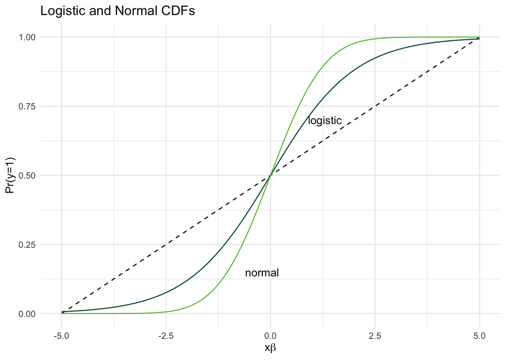

Figure 1

```r
z <- seq(-5,5,.1)
l <- seq(0,1,.01)
s1 <- 1/(1+exp(-z))
s2 <- pnorm(z)

df <- data.frame(z=z, l=l, s1=s1, s2=s2)

ggplot(df, aes(x=z, y=l)) +
  geom_line(aes(x=z, y=l), color="black", linetype="dashed" )+
  geom_line(aes(x=z, y=s1), color="#005A43")+
  geom_line(aes(x=z, y=s2), color="#6CC24A")+
  labs(title="Logistic and Normal CDFs", x=expression(x*beta), y="Pr(y=1)")+
  theme_minimal() +
  annotate("text", x=1.3, y=.7, label="logistic", color="black")+
  annotate("text", x=-.2, y=.15, label="normal", color="black")
```

Note the sigmoid functions approach the limits at decreasing rates; the fastest rate of change is at $y=.5$, a point around which the curves are symmetric. The point $y=.5$ is the transition point below which we’d predict a zero, above which we’d predict a one if we were interested in classifying cases into zeros and ones. Classification is a common use for models like these, say distinguishing spam from non-spam emails, or predicting the presence or absence of a disease. More on this later.

## Probit and Logit LLFs

Probit - link between $x\hat{\beta}$ and $Pr(y=1)$ is standard normal CDF:
$$\ln \mathcal{L} (Y|\beta) = \sum_{i=1}^{N} y_i \ln \Phi(\mathbf{x_i \beta})+ (1-y_i) \ln[1-\Phi(\mathbf{x_i \beta})] \nonumber$$

Logit (logistic CDF):

$$\ln \mathcal{L} (Y|\beta) = \sum_{i=1}^{N} \left\{ y_i \ln \left(\frac{1}{1+e^{-\mathbf{x_i \beta}}}\right)+ (1-y_i) \ln \left[1-\left(\frac{1}{1+e^{-\mathbf{x_i \beta}}}\right)\right] \right\}\nonumber$$

# Binary response interpretation

- Signs and significance - all the usual rules apply.
- Quantities of interest - most commonly $Pr(y=1|X)$; or marginal effects.
- Measures of uncertainty (e.g. confidence intervals) are a must (as always).

For details on prediction approaches, methods, and code, please see the [predictions](https://clavedark.github.io/MLEfall24/prediction24.html) notes.

## Predicted probabilities

In the nonlinear model, the most basic quantity is

$$F(x\widehat{\beta})$$

where $F$ is the link function, mapping the linear prediction onto the probability space.

For the logit, the predicted probability is

$$Pr(y=1) = \frac{1}{1+exp(-x\widehat{\beta})}$$

For the probit, the predicted probability is

$$Pr(y=1) = \Phi(x\widehat{\beta})$$

Again, simply using the link function to map the linear prediction onto the probability space.

## Marginal Effects

In the linear model, the marginal effect of $x$ is $\widehat{\beta}$. That is, the effect of a one unit change in $x$ on $y$ is $\widehat{\beta}$.

$$\frac{\partial \widehat{y}}{\partial x_k}= \frac{\partial x \widehat{\beta}}{\partial x_k} \nonumber \\ \nonumber \\
= \widehat{\beta} \nonumber$$

The marginal effect is constant with respect to $x_k$. Take a look:

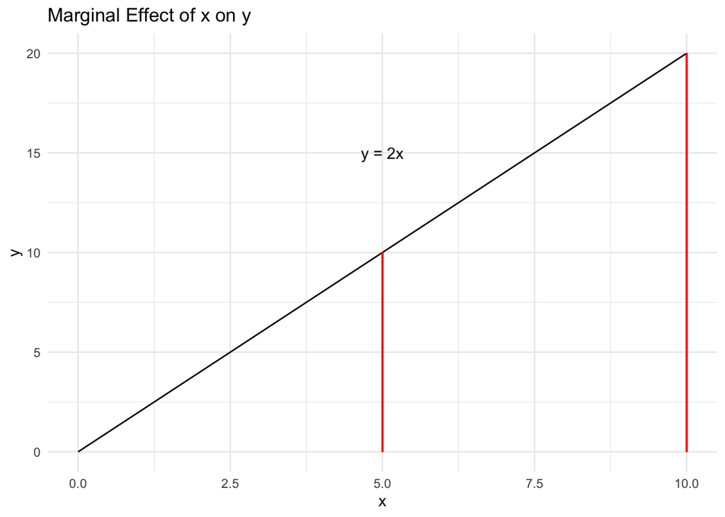

```r
x <- seq(0,10,.1)
y <- 2*x
df <- data.frame(x=x, y=y)

ggplot(df, aes(x=x, y=y)) +
  geom_line()+
  labs(title="Marginal Effect of x on y", x="x", y="y")+
  theme_minimal() +
  annotate("text", x=5, y=15, label="y = 2x", color="black")+
  geom_segment(aes(x = 5, xend = 5, y = 0, yend = 10), color = "red")+
  geom_segment(aes(x = 10, xend = 10, y = 0, yend = 20), color = "red")
```

The effect of $x$ on $y$ is 2 - it’s the same at $x=5$ and at $x=10$.

In the **nonlinear model**, the marginal effect of $x_k$ depends on where $x\widehat{\beta}$ lies with respect to the probability distribution $F(\cdot)$.

$$\frac{\partial Pr(y=1)}{\partial x_k}= \frac{\partial F(x\widehat{\beta})}{\partial x_k} \nonumber \\ \nonumber \\
= \frac{\partial F(x\widehat{\beta})}{\partial x\widehat{\beta}} \cdot \frac{\partial (x\widehat{\beta})}{\partial x_k} \nonumber$$

Both of these terms simplify …

Remember that

$$\frac{\partial (x\widehat{\beta})}{\partial x} = \widehat{\beta} \nonumber$$

and
$$\frac{\partial F(x\widehat{\beta})}{\partial x\widehat{\beta}} = f(x\widehat{\beta}) \nonumber$$

where the derivative of the CDF is the PDF.

Putting these together gives us:

$$\frac{\partial F(x\widehat{\beta})}{\partial x\widehat{\beta}} = f(x\widehat{\beta}) \widehat{\beta} \nonumber$$

This is $\widehat{\beta}$ weighted by or measured at the ordinate on the PDF - the ordinate is the height of the PDF associated with a value of the $x$ axis.

**Important Concept**

The effect of $x$ on $Pr(y=1)$ is not constant; it will be large for some values of $x$ and small for others. This makes sense if we think about the sigmoid functions - the slope of the curve is steepest at $y=.5$, and flattens as we move away from that point toward either limit. Take another look at Figure 1

### Logit Marginal Effects

Recall $\Lambda$ is the logistic CDF =
$$1/(1+exp(-x_i\widehat{\beta}))$$
.

Also, remember that

$$\frac{e^{x_i\widehat{\beta}}}{1+e^{x_i\widehat{\beta}}} = \frac{1}{1+e^{-x_i\widehat{\beta}}}$$

$$\begin{align}
\frac{\partial \Lambda(x\widehat{\beta})}{\partial x\widehat{\beta}} = \lambda(x\widehat{\beta}) \widehat{\beta} \\
= \frac{e^{x_i\widehat{\beta}}}{(1+e^{x_i\widehat{\beta}})^2} \widehat{\beta} \\
=\frac{e^{x_i\widehat{\beta}}}{1+e^{x_i\widehat{\beta}}} \frac{1}{1+e^{x_i\widehat{\beta}}} \widehat{\beta} \\
=\Lambda(x_i\widehat{\beta}) \frac{1+e^{x_i\widehat{\beta}}-e^{x_i\widehat{\beta}}}{1+e^{x_i\widehat{\beta}}} \widehat{\beta} \\
=\Lambda(x_i\widehat{\beta}) 1-\frac{e^{x_i\widehat{\beta}}}{1+e^{x_i\widehat{\beta}}} \widehat{\beta} \\
=\Lambda(x_i\widehat{\beta}) (1-\Lambda(x_i\widehat{\beta})) \widehat{\beta}
\end{align}$$

So this last line indicates the marginal effect of $x$ is the probability of a one times the probability of a zero times $\widehat{\beta}$.

This is useful because the largest value this can take on is .25 $(Pr(y_i=1)=0.5 \cdot Pr(y_i=0)=0.5= 0.25)$ - therefore, the maximum marginal effect any $x$ can have is $0.25 \widehat{\beta}$.

Looking at the democratic peace model below, the coefficient on democracy is -.071, so the largest effect democracy can have on the probability of a militarized dispute is $0.25 \cdot -.071 = -.01775$.

```r
library(stargazer)

stargazer(m1,m2, type="html",  single.row=TRUE, header=FALSE, digits=3,  omit.stat=c("LL","ser"),  star.cutoffs=c(0.05,0.01,0.001),    dep.var.caption="Dependent Variable: Dispute", dep.var.labels.include=FALSE,  covariate.labels=c("Shared Border", "Democracy", "Capabilities Ratio", "Allies"),  notes=c("Standard errors in parentheses", "Significance levels:  *** p<0.001, ** p<0.01, * p<0.05"), notes.append = FALSE,  align=TRUE,  font.size="small")
```

|  | Dependent Variable: Dispute |  |
| --- | --- | --- |
|  | *logistic* | *probit* |
|  | (1) | (2) |
| Shared Border | 1.221*** (0.078) | 0.587*** (0.037) |
| Democracy | -0.071*** (0.007) | -0.031*** (0.003) |
| Capabilities Ratio | -0.003*** (0.0004) | -0.001*** (0.0001) |
| Allies | -0.806*** (0.080) | -0.350*** (0.038) |
| Constant | -3.492*** (0.075) | -1.903*** (0.032) |
| Observations | 20,990 | 20,990 |
| Akaike Inf. Crit. | 7,011.947 | 7,032.985 |
| *Note:* | Standard errors in parentheses |  |
|  | Significance levels: *** p<0.001, ** p<0.01, * p<0.05 |  |

In the probit model, the marginal effect is:

$$\frac{\partial \Phi(x\widehat{\beta})}{\partial x\widehat{\beta}} = \phi(x\widehat{\beta}) \widehat{\beta} \nonumber$$

The ordinate at the maximum of the standard normal PDF is 0.3989 - rounding to 0.4, we can say that the maximum marginal effect of any $\widehat{\beta}$ in the probit model is $0.4\widehat{\beta}$.

The ordinate is at the maximum where $z=0$; recall this is the standard normal, so $x_i\widehat{\beta}=z$. When $z=0$,

$$Pr(z)=\frac{1}{\sqrt{2 \pi}} \exp \left[\frac{-(z)^{2}}{2}\right] \nonumber \\ \nonumber\\
=\frac{1}{\sqrt{2 \pi}} \nonumber\\
\approx .4 \nonumber$$

So the maximum marginal effect of any $x$ in the probit model is $0.4\widehat{\beta}$.

Here are the logistic and normal PDFs, with the maximum marginal effects indicated by dashed lines - you’ll see the maxima are at .25 for the logit, and .4 for the standard normal (probit) .

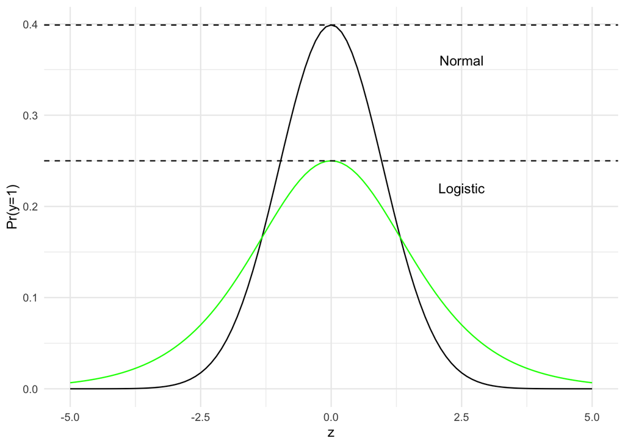

```r
z <- seq(-5,5,.1)
ncdf <- pnorm(z)
npdf <- dnorm(z)
lcdf <- plogis(z)
lpdf <- dlogis(z)

df <- data.frame(ncdf=ncdf, npdf=npdf, lcdf=lcdf, lpdf=lpdf, z=z)

ggplot(df, aes(x=z, y=npdf), color="black") +
  geom_line() +
  geom_line(aes(x=z, y=lpdf), color="green") +
  geom_hline(yintercept = .3989, linetype="dashed") +
  geom_hline(yintercept = .25, linetype="dashed") +
  labs(x="z", y="Pr(y=1)") +
  theme_minimal() +
  annotate("text", x = 2.5, y = .36, label = "Normal", color = "black") +
  annotate("text", x = 2.5, y = .22, label = "Logistic", color = "black")
```

## Logit Odds Interpretation

The odds are given by the probability an event occurs divided by the probability it does not:

$$\Omega(X) = \frac{Pr(y=1)}{1-Pr(y=1)} \nonumber
= \frac{\Lambda(X\widehat{\beta})}{(1-\Lambda(X\widehat{\beta}))} \nonumber$$

## Logit Log-odds

Logging …

$$\ln \Omega(X) = \ln \left(\frac{\Lambda(X\widehat{\beta})}{(1-\Lambda(X\widehat{\beta}))}\right) =X\widehat{\beta}$$

$$\frac{\partial \ln \Omega}{\partial X} = \widehat{\beta} \nonumber$$

Which shows the change in the log-odds given a change in $X$ is constant (and therefore linear). This quantity is sometimes called “the logit.”

## Logit Odds Ratios

Odds ratios are very useful:

$$\frac{ \Omega x_k + 1}{\Omega x_k} =exp(\widehat{\beta_k}) \nonumber$$

comparing the difference in odds between two values of $x_k$; note the change in value does not have to be 1.

$$\frac{ \Omega x_k + \iota}{\Omega x_k} =exp(\widehat{\beta_k}* \iota) \nonumber$$

Not only is it simple to exponentiate $\widehat{\beta_k}$, but the interpretation is that $x$ increases/decreases $Pr(y=1)$ by that factor, $exp(\widehat{\beta_k})$, and more usefully, that:

$$100*(exp(\widehat{\beta_k})-1) \nonumber$$

is the percentage change in the odds given a one unit change in $x_k$.

So a logit coefficient of .226

$$100*(exp(.226)-1) =25.36 \nonumber$$

Produces a 25.36% increase in the odds of $y$ occurring.

# Section 3: Prediction methods for binary response models

# Predictions in MLE Models

Most MLE models are nonlinear, so their coefficients are not their marginal effects. As a result, most MLE models require a transformation of the linear prediction to generate quantities of interest. The methods outlined here apply to most MLE applications; the immediate interest and examples here use binary response models. These slides will form a foundation for prediction in other types of models we encounter.

## Binary response models

Probit and logit coefficients **are** directly interpretable in the senses that

- We can interpret direction.
- We can interpret statistical difference from zero.
- We can say the largest marginal effect of $x \approx 0.4\cdot\widehat{\beta}$ for the probit model.
- We can say the largest marginal effect of $x \approx 0.25\cdot\widehat{\beta}$ for the logit model.
- We can say that $exp(\widehat{\beta_k})-1$ is the percentage change in the odds that $y=1$, for the logit model.

It’s still the case that we often want other **quantities of interest** like probabilities, and that requires the straightforward transformations of the linear prediction, $F(x_i\widehat{\beta})$.

Let’s look briefly at the intuition of the “maximum marginal effect” in the logit model.

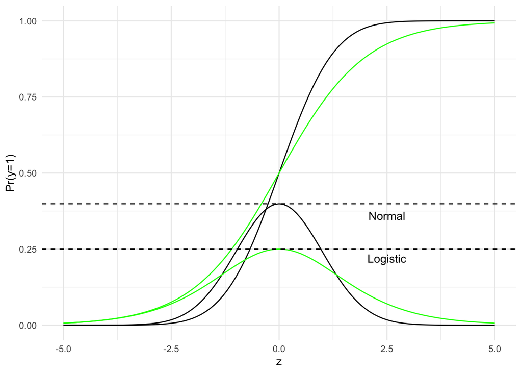

```r
z <- seq(-5,5,.1)
ncdf <- pnorm(z)
npdf <- dnorm(z)
lcdf <- plogis(z)
lpdf <- dlogis(z)

df <- data.frame(ncdf=ncdf, npdf=npdf, lcdf=lcdf, lpdf=lpdf, z=z)

ggplot(df, aes(x=z, y=ncdf), color="black") +
  geom_line() +
  geom_line(aes(x=z, y=lcdf), color="green") +
  geom_line(aes(x=z, y=npdf), color="black") +
  geom_line(aes(x=z, y=lpdf), color="green") +
  geom_hline(yintercept = .3989, linetype="dashed") +
  geom_hline(yintercept = .25, linetype="dashed") +
  labs(x="z", y="Pr(y=1)") +
  theme_minimal() +
  annotate("text", x = 2.5, y = .36, label = "Normal", color = "black") +
  annotate("text", x = 2.5, y = .22, label = "Logistic", color = "black")
```

The highest points on the PDFs indicate the maximum marginal effect of $x$ on $Pr(y=1)$ in the logit and probit models.

# Approaches to prediction

It’s important to note that these approaches and most of the technique described in these slides the same in most other MLE models and in the linear OLS model.

- **At-Means Predictions** - set variables to means/medians/modes, vary $x$ of interest, generate effect.
- **Average Effects** - set $x$ of interest to value of interest leaving all other variables at real values, then predict, average, then repeat at next value of interest.

## At-Means Predictions

At-means predictions are what they sound like - effects with independent variables set at central tendencies. These are sometimes called “adjusted predictions.”

- estimate model.
- create out of sample data.
- vary $x$ of interest; set all other $x$ variables to appropriate central tendencies - hence the “at Means.”
- generate QIs in out of sample data.

## Average Effects

Average Marginal Effects are in-sample but create a counterfactual for a variable of interest, assuming the entire sample looks like that case.

For instance, suppose a model of wages with covariates for education and gender. We might ask the question *what would the predictions look like if the entire sample were male, but otherwise looked as it does?* Alternatively, *what would the predictions look like if the entire sample were female, but all other variables the same as they appear in the estimation data?*

To answer these, we’d change the gender variable to *male*, generate $x{\widehat{\beta}}$ for the entire sample, and take the average, then repeat with the gender variable set to *female*.

To generate Average Effects,

- estimate model.
- in estimation data, set variable of interest to a particular value for the entire estimation sample.
- generate QIs (expected values, standard errors).
- take average of QIs, and save.
- repeat for all values of variable of interest, and plot.

# Methods for Quantities of Interest

Again, these are the same as in the linear model:

- direct computation - generate $F(x\widehat{\beta})$ for interesting values of $x$ (either as At-Means or Average Effects).
- simulation of $\widehat{\beta}$
- simulation of QI.

## At-means predictions (logit)

Here’s an example of at-means predictions for a logit model of the democratic peace. FIrst, let’s look at the model estimates:

```r
dp <- read_dta("/Users/dave/Documents/teaching/501/2023/slides/L7_limiteddv/code/dp.dta")

m1 <-glm(dispute ~ border+deml+caprat+ally, family=binomial(link="logit"), data=dp )

stargazer(m1, type="html",  single.row=TRUE, header=FALSE, digits=3,  omit.stat=c("LL","ser"),  star.cutoffs=c(0.05,0.01,0.001),    dep.var.caption="Dependent Variable: Dispute", dep.var.labels.include=FALSE,  covariate.labels=c("Shared Border", "Democracy", "Capabilities Ratio", "Allies"),  notes=c("Standard errors in parentheses", "Significance levels:  *** p<0.001, ** p<0.01, * p<0.05"), notes.append = FALSE,  align=TRUE,  font.size="small")
```

|  | Dependent Variable: Dispute |
| --- | --- |
| Shared Border | 1.221*** (0.078) |
| Democracy | -0.071*** (0.007) |
| Capabilities Ratio | -0.003*** (0.0004) |
| Allies | -0.806*** (0.080) |
| Constant | -3.492*** (0.075) |
| Observations | 20,990 |
| Akaike Inf. Crit. | 7,011.947 |
| *Note:* | Standard errors in parentheses |
|  | Significance levels: *** p<0.001, ** p<0.01, * p<0.05 |

As with any nonlinear model, we need to compute a linear prediction, $x\widehat{\beta}$, and then transform that to a probability. For at-means predictions, we’ll vary democracy across its range, holding the remaining variables at appropriate central tendency (e.g, mode for dummy variables, median for categorical or skewed variables, etc.) Take a look at the code:

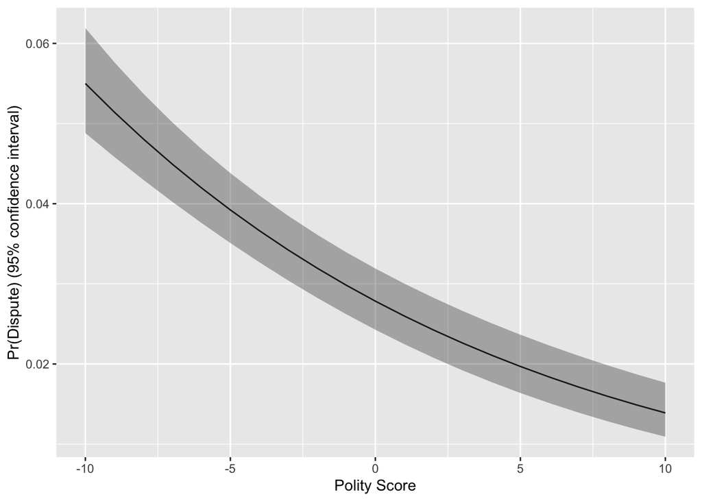

```r
dp <- read_dta("/Users/dave/Documents/teaching/501/2023/slides/L7_limiteddv/code/dp.dta")

m1 <-glm(dispute ~ border+deml+caprat+ally, family=binomial(link="logit"), data=dp )
logitpreds <- predict(m1, type="response")

m2 <-glm(dispute ~ border+deml+caprat+ally, family=binomial(link="probit"), data=dp )

#new data frame for MEM prediction
mem <- data.frame(deml= c(seq(-10,10,1)),
                  border=0, caprat=median(dp$caprat), ally=0)

# type="link" produces the linear predictions; transform by hand below w/EPT
mem  <-data.frame(mem, predict(m1, type="link", newdata=mem, se=TRUE))

mem <- cbind(mem,lb=plogis(mem$fit-1.96*mem$se.fit),
             ub=plogis(mem$fit+1.96*mem$se.fit),
             p=plogis(mem$fit))

ggplot(mem, aes(x=deml, y=p)) +
  geom_line() +
  geom_ribbon(data=mem, aes(x=deml, ymin=lb, ymax=ub),fill = "grey30", alpha = .4, ) +
  labs(x="Polity Score", y="Pr(Dispute) (95% confidence interval)")
```

## Average effects (logit)

Average effects are often a better choice because they represent the data more completely than central tendency can (in the at-mean effects). Here are average effects (using the logit estimates) across the range of polity, and for pairs of states that share borders and those that do not.

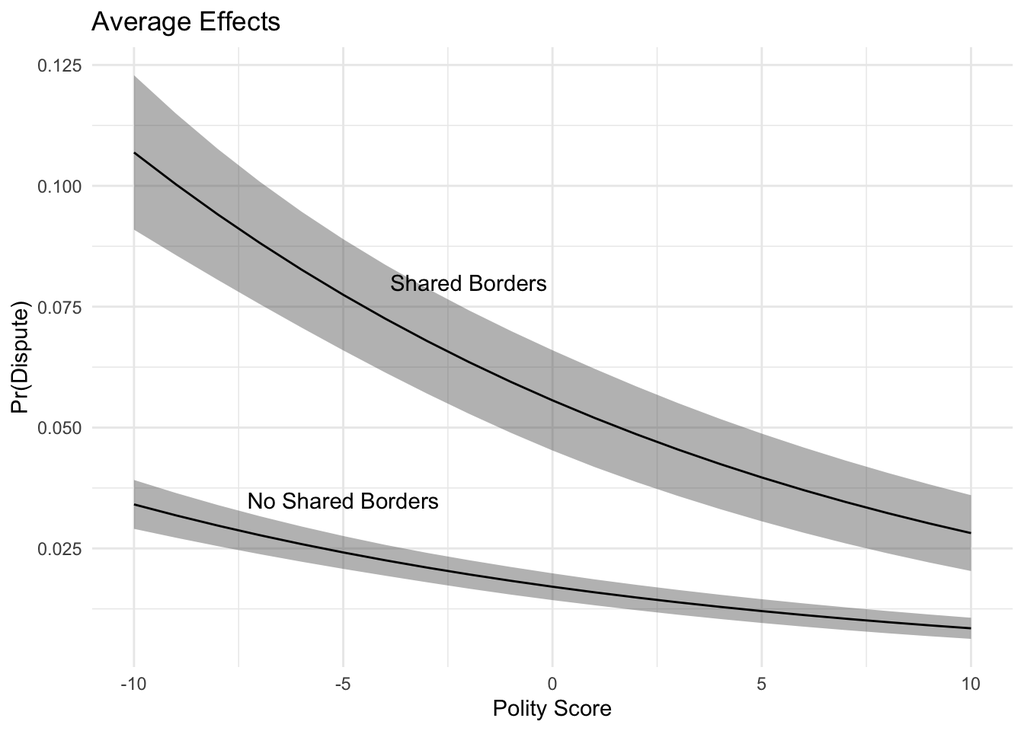

```r
#avg effects

#identify the estimation sample
dp$used <- TRUE
dp$used[na.action(m1)] <- FALSE
dpesample <- dp %>%  filter(used=="TRUE")

polity <- 0
medxbd0 <- 0
ubxbd0 <- 0
lbxbd0 <- 0
# medse <- 0
# medxbd1 <- 0
# ubxbd1 <- 0
# lbxbd1 <- 0

for(i in seq(1,21,1)){
  dpesample$border<- 0
  dpesample$deml <- i-11
  polity[i] <- i-11
  allpreds <- data.frame(predict(m1, type= "response", se.fit=TRUE, newdata = dpesample))
  medxbd0[i] <- median(allpreds$fit, na.rm=TRUE)
  ubxbd0[i] <- median(allpreds$fit, na.rm=TRUE)+1.96*(median(allpreds$se.fit, na.rm=TRUE))
  lbxbd0[i] <- median(allpreds$fit, na.rm=TRUE)-1.96*(median(allpreds$se.fit, na.rm=TRUE))
}

noborder <- data.frame(polity, medxbd0, ubxbd0, lbxbd0)

for(i in seq(1,21,1)){
  dpesample$border<- 1
  dpesample$deml <- i-11
  polity[i] <- i-11
  allpreds <- data.frame(predict(m1, type= "response", se.fit=TRUE, newdata = dpesample))
  medxbd0[i] <- median(allpreds$fit, na.rm=TRUE)
  ubxbd0[i] <- median(allpreds$fit, na.rm=TRUE)+1.96*(median(allpreds$se.fit, na.rm=TRUE))
  lbxbd0[i] <- median(allpreds$fit, na.rm=TRUE)-1.96*(median(allpreds$se.fit, na.rm=TRUE))
}

border <- data.frame(polity, medxbd0, ubxbd0, lbxbd0)



ggplot() +
  geom_ribbon(data=noborder, aes(x=polity, ymin=lbxbd0, ymax=ubxbd0),fill = "grey30", alpha = .4, ) +
  geom_line(data=noborder, aes(x=polity, y=medxbd0))+
  geom_ribbon(data=border, aes(x=polity, ymin=lbxbd0, ymax=ubxbd0),fill = "grey30", alpha = .4, ) +
  geom_line(data=border, aes(x=polity, y=medxbd0))+
  labs ( colour = NULL, x = "Polity Score", y =  "Pr(Dispute)" )+
  theme_minimal()+
  ggtitle("Average Effects") +
  annotate("text", x = -2, y = .08, label = "Shared Borders", color = "black") +
  annotate("text", x = -5, y = .035, label = "No Shared Borders", color = "black")
```

## Simulation

Simulation is an especially good approach for nonlinear models:

- estimate the model.
- $m$ times (say, 1000 times), simulate the distribution of $\widehat{\beta}$.
- generate the $m$ linear predictions, $x\widehat{\beta}$.
- transform by the appropriate link function (logistic, standard normal CDF).
- identify the 2.5, 50, and 97.5 percentiles.
- plot against $x$.

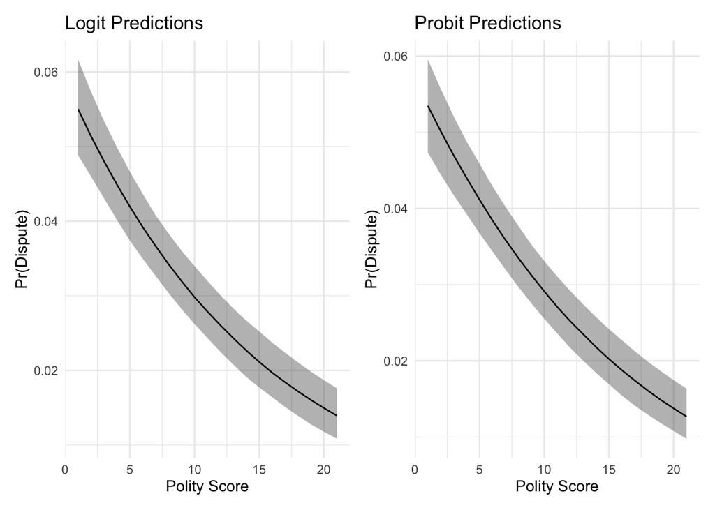

```r
#draws from multivariate normal using logit model estimates
simL <- data.frame(MASS::mvrnorm(1000, coef(m1), vcov(m1)))
#draws from multivariate normal using probit model estimates
simP <- data.frame(MASS::mvrnorm(1000, coef(m2), vcov(m2)))

#Logit predictions
logitprobs <- data.frame(dem= numeric(0) , lb=numeric(0), med= numeric(0), ub=numeric(0))
for (i in seq(1,21,1)) {
simpreds <- quantile(simL$X.Intercept.+ simL$border*0+simL$deml*(i-11)+simL$caprat*median(dp$caprat)+simL$ally*0, probs=c(.025, .5, .975))
logitprobs[i,] <- data.frame(dem=i, lb=plogis(simpreds[1]), med=plogis(simpreds[2]), ub=plogis(simpreds[3]))
}

#Probit predictions
probitprobs <- data.frame(dem= numeric(0) , lb=numeric(0), med= numeric(0), ub=numeric(0))
for (i in seq(1,21,1)) {
simpreds <- quantile(simP$X.Intercept.+ simP$border*0+simP$deml*(i-11)+simP$caprat*median(dp$caprat)+simP$ally*0, probs=c(.025, .5, .975))
probitprobs[i,] <- data.frame(dem=i, lb=pnorm(simpreds[1]), med=pnorm(simpreds[2]), ub=pnorm(simpreds[3]))
}

logit <- ggplot() +
  geom_ribbon(data=logitprobs, aes(x=dem, ymin=lb, ymax=ub),fill = "grey30", alpha = .4, ) +
  geom_line(data=logitprobs, aes(x=dem, y=med))+
  labs ( colour = NULL, x = "Polity Score", y =  "Pr(Dispute)" )+
  theme_minimal()+
  ggtitle("Logit Predictions")

probit <- ggplot() +
  geom_ribbon(data=probitprobs, aes(x=dem, ymin=lb, ymax=ub),fill = "grey30", alpha = .4, ) +
  geom_line(data=probitprobs, aes(x=dem, y=med))+
  labs ( colour = NULL, x = "Polity Score", y =  "Pr(Dispute)" )+
  theme_minimal()+
  ggtitle("Probit Predictions")

logit+probit
```

## Simulating combinations of binary variables

Let’s look at the differences among the four combinations of the binary variables, border and ally.

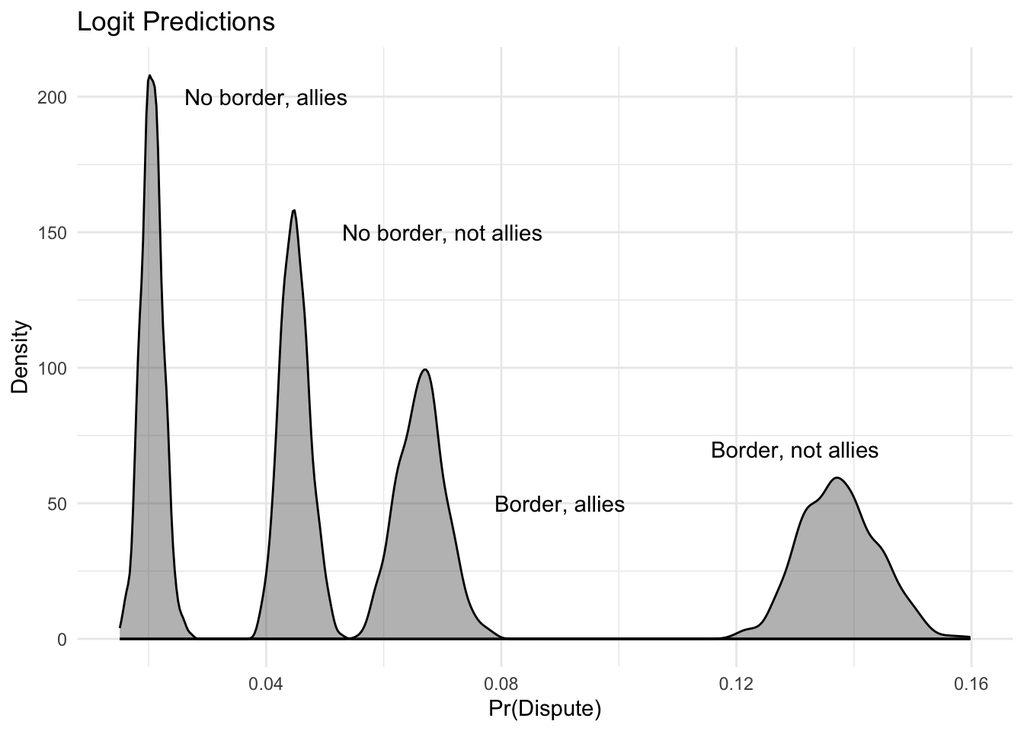

```r
## simulating for binary combinations ----

m1 <-glm(dispute ~ border+deml+caprat+ally, family=binomial(link="logit"), data=dp )

#draws from multivariate normal using logit model estimates
simL <- data.frame(MASS::mvrnorm(1000, coef(m1), vcov(m1)))


logitprobs <- data.frame(b0a0= numeric(0) , b1a0=numeric(0), b0a1= numeric(0), b1a1=numeric(0))

  b0a0 <- plogis(simL$X.Intercept.+ simL$border*0+simL$deml*-7+simL$caprat*median(dp$caprat)+simL$ally*0)
b1a0 <- plogis(simL$X.Intercept.+ simL$border*1+simL$deml*-7+simL$caprat*median(dp$caprat)+simL$ally*0)
b0a1 <- plogis(simL$X.Intercept.+ simL$border*0+simL$deml*-7+simL$caprat*median(dp$caprat)+simL$ally*1)
b1a1 <- plogis(simL$X.Intercept.+ simL$border*1+simL$deml*-7+simL$caprat*median(dp$caprat)+simL$ally*1)

logitprobs <- data.frame(b0a0, b1a0, b0a1, b1a1)

ggplot() +
  geom_density(data=logitprobs, aes(x=b0a0), fill="grey30", alpha = .4, ) +
  geom_density(data=logitprobs, aes(x=b1a0), fill="grey30", alpha = .4, ) +
  geom_density(data=logitprobs, aes(x=b0a1), fill="grey30", alpha = .4, ) +
  geom_density(data=logitprobs, aes(x=b1a1), fill="grey30", alpha = .4, ) +
  labs ( colour = NULL, x = "Pr(Dispute)", y =  "Density" ) +
  theme_minimal()+
  annotate("text", x = .07, y = 150, label = "No border, not allies", color = "black") +
  annotate("text", x = .13, y = 70, label = "Border, not allies", color = "black") +
  annotate("text", x = .04, y = 200, label = "No border, allies", color = "black") +
  annotate("text", x = .09, y = 50, label = "Border, allies", color = "black") +
  ggtitle("Logit Predictions")
```

# Uncertainty

So far, we hve focused on generating a predicted value from the model. Let’s think about generating measures of uncertainty for those predicted values.

This section examines ways to compute standard errors, and ways to use those to compute confidence intervals.

## ML Standard Errors of Linear Predictions

One commonly used measure of uncertainty is the standard error of the linear prediction, $X\widehat{\beta}$.

Consider the linear prediction

$$X \widehat{\beta}$$

under maximum likelihood theory:

$$var(X \widehat{\beta}) = \mathbf{X V X'}$$

an $N x N$ matrix, where $V$ is the var-cov matrix of ${\widehat{\beta}}$. The main diagonal contains the variances of the $N$ predictions. The standard errors are:

$$se(X \widehat{\beta}) = \sqrt{diag(\mathbf{X V X'})}$$

which is an $N x 1$ vector. So now we have a column vector of standard errors for the linear prediction, $X\widehat{\beta}$. Like the linear predictions, these are *not* transformed into probabilities, so when we compute confidence intervals, we need to map the upper and lower bounds onto the probability space.

$$F(X \widehat{\beta} - c*s.e.) \leq F(X \widehat{\beta}) \leq F(X \widehat{\beta} + c* s.e.)$$

## Delta Method standard errors

$$Var[F(X \widehat{\beta})] = f(\mathbf{x'\widehat{\beta}})^2 \mathbf{x' V x}$$

where this would generate variances for whatever $F(X \widehat{\beta})$ is, perhaps a predicted probability.

### Delta method standard errors for Logit

For the logit, the delta standard errors are given by:

$$F(X \widehat{\beta}) * (1-F(X \widehat{\beta}) * \mathbf(X V X')$$

$$= f(X \widehat{\beta}) * \mathbf{\sqrt{X V X'}}$$

or

$$p * (1-p) * stdp$$

where $stdp$ is the standard error of the linear prediction.

## SEs of Predictions for linear combinations

A common circumstance that requires joint hypothesis tests is the case of polynomials (which are themselves interactions):

$$y = \widehat{\beta}_0 + \widehat{\beta}_1 x_1 + \widehat{\beta}_2 x_{1}^2 + \varepsilon$$

The question is whether $\widehat{\beta}_1 = \widehat{\beta}_2 = 0$ - the marginal effect is:

$$\widehat{\beta}_1 + 2 \widehat{\beta}_2x_1$$

and requires the standard error for $\widehat{\beta}_1+\widehat{\beta}_2$, which is:

$$\sqrt{var(\widehat{\beta}_1) + 4x_{1}^{2}var(\widehat{\beta}_2) + 4x_1 cov(\widehat{\beta}_1, \widehat{\beta}_2) }$$

## CIs - End Point Transformation

Generate upper and lower bounds using either ML or Delta standard errors, such that

$$F(X \widehat{\beta} - c*s.e.) \leq F(X \widehat{\beta}) \leq F(X \widehat{\beta} + c* s.e.)$$

- estimate the model, generate the linear prediction, and the standard error of the linear prediction using the either ML or Delta.
- generate linear boundary predictions, $x{\widehat{\beta}} \pm c * \text{st. err.}$ where $c$ is a critical value on the normal, eg. $z=1.96$.
- transform the linear prediction and the upper and lower boundary predictions by $F(\cdot)$.
- With ML standard errors, EPT boundaries will obey distributional boundaries (ie, won’t fall outside 0-1 interval for probabilities); the linear end point predictions are symmetric, though they will not be symmetric in nonlinear models.
- With delta standard errors, bounds may not obey distributional boundaries.

## Simulating confidence intervals, I

- draw a sample with replacement of size $\tilde{N}$ from the estimation sample.
- estimate the model parameters in that bootstrap sample.
- using the bootstrap estimates, generate quantities of interest (e.g. $x\widehat{\beta}$) repeat $j$ times.
- collect all these bootstrap QIs and use either percentiles or standard deviations to measure uncertainty.

## Uncertainty: Simulating confidence intervals, II

- estimate the model.
- generate a large sample distribution of parameters (e.g. using drawnorm).
- generate quantities of interest for the distribution of parameters.
- use either percentiles or standard deviations of the QI to measure uncertainty.

# Section 4: Discrete Hazards

# Goals

- consider what “memory” might look like in a binary time series setting.
- introduce concepts underlying hazard models.
- understand the discrete time hazard model.

# Temporal Dependence

So far, we have explored binary response models in terms of the structure of the LLF, estimation, and interpretation. Today, we’ll focus on the assumption the errors are independent over time - what we’ll call temporal independence.

**Temporal independence** requires that $cov(\varepsilon_t, \varepsilon_t-k)=0$ - that the errors are not correlated across time. It implies that observations on $y$ are independent of one another.

Put differently, the process that generates $y$ is memory-less.

# Memory in models

In the linear model, we considered several ways present-day values of $y$ might arise as a function of things that happened in the past (either at lagged values of $y$, or past values of $x$ variables).

In the binary model, we need to consider the same sort of dynamics, but lagging the $y$ variable does not exactly measure persistence - it would only measure whether the presence/absence of $y$ in the last period affects present day values of $y$. What we’d really like to measure is how the latent probability $y=1$ in the past affects the probability $y=1$ today.

# Binary models so far …

```r
dp <- read_dta("/Users/dave/Documents/teaching/501/2023/slides/L7_limiteddv/code/dp.dta")

dpm1 <-glm(dispute ~ border+deml+caprat+ally, family=binomial(link="logit"), data=dp )

stargazer(dpm1, type="html",  single.row=TRUE, header=FALSE, digits=3,  omit.stat=c("LL","ser"),  star.cutoffs=c(0.05,0.01,0.001),    dep.var.caption="Dependent Variable: Dispute", dep.var.labels.include=FALSE,  covariate.labels=c("Shared Border", "Democracy", "Capabilities Ratio", "Allies"),  notes=c("Standard errors in parentheses", "Significance levels:  *** p<0.001, ** p<0.01, * p<0.05"), notes.append = FALSE,  align=TRUE,  font.size="small")
```

|  | Dependent Variable: Dispute |
| --- | --- |
| Shared Border | 1.221*** (0.078) |
| Democracy | -0.071*** (0.007) |
| Capabilities Ratio | -0.003*** (0.0004) |
| Allies | -0.806*** (0.080) |
| Constant | -3.492*** (0.075) |
| Observations | 20,990 |
| Akaike Inf. Crit. | 7,011.947 |
| *Note:* | Standard errors in parentheses |
|  | Significance levels: *** p<0.001, ** p<0.01, * p<0.05 |

What is the effect of democracy if the dyad has been at peace for 2 years?

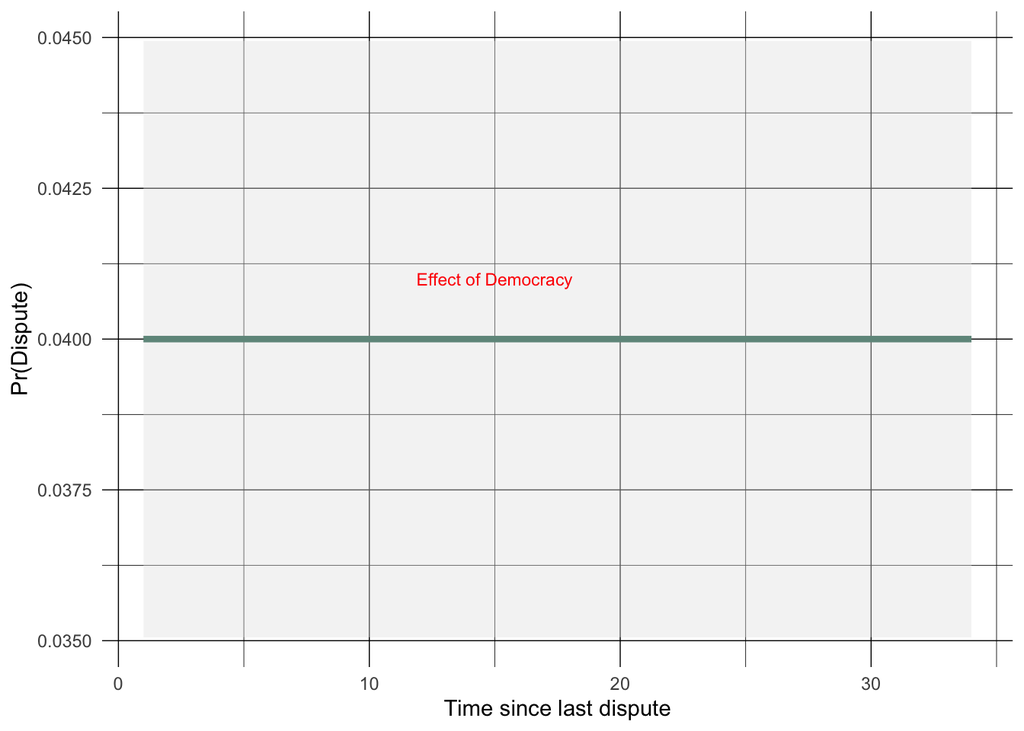

```r
# at mean data over 30 observations

atmean <- data.frame(stime=seq(1,34,1), deml=median(dp$deml), border=0, caprat=median(dp$caprat), ally=0)

predictions <- data.frame(atmean, predict(dpm1, newdata=atmean, type="response", se=TRUE)) %>% mutate(fit=round(fit, 2) )


ggplot(predictions, aes(x=stime, y=fit)) +
  geom_line(color="#005A43", size=1.5) +
  labs(x="Time since last dispute", y="Pr(Dispute)") +
  geom_ribbon(aes(ymin=fit-1.96*se.fit, ymax=fit+1.96*se.fit), fill="grey90", alpha=0.4) +
  theme_minimal() +
  annotate("text", x = 15, y = 0.041, label = "Effect of Democracy", color = "red", size = 3) +
  theme(panel.grid.major = element_line(color = "black",
                                        size = 0.25,
                                        linetype = 1)) +
  theme(panel.grid.minor = element_line(color = "black",
                                        size = 0.15,
                                        linetype = 1))
```

What is the effect of democracy if the dyad has been at peace for 22 years? Obviously, there is no difference in this model because we didn’t account for time. In effect, we assumed each period is independent of any other, so there is no memory across observations. The effects of the $x$ variables like democracy are assumed constant over time.

## Memoryless

By construction, this model lacks any memory. $Pr(Y_{i,t}=1)$ is a function of $X_{i,t}$, but is independent of anything that happened prior to $t$.

This means dyads that have been at peace for 2 years and for 22 years are treated as the same, varying only on the $X$ variables.

Note this is by choice - we’re assuming $y_t$ has no bearing on $y_{t+1}$, so there is no persistence or memory from period to period. We’ll encounter a range of models that are explicitly aimed at understanding this question: **How does having survived up until now affect the chances of failing now?**

## Data

The democratic peace data is panel data - composed of cross sections observed over time. The $y$ variable is binary, and measures a rare event - conflict. So the $y$ variable for any particular panel is usually a string of zeros, occasionally punctuated by a one.

What we’d really like to know is if/how strings of zeros affect the chances of a one at any given point in time. This is a question of **hazards**.

# Hazards

The hazard is the probability of failure at a particular point in time, conditional on having survived up until that point. Asking about the chances something comes to an end without also asking how long it’s lasted so far often doesn’t make much sense.

Consider human mortality as an example:

- What is the probability of death for a 2 year old white male in the US, all else equal?
- What is the probability of death for a 22 year old white male in the US, all else equal?
- What is the probability of death for a 92 year old white male in the US, all else equal?

It’s possible (likely?) these probabilities are all similar if not the same because we’re asking the wrong question. We’re considering all these probabilities unconditionally though a potentially important condition is that

- The 2 year old has survived up until 2.
- The 22 year old has survived up until 22.
- The 92 year old has survived up until 92.

When we think about whether a unit fails at a particular point in time, it’s essential to consider how long they’ve survived up to that point. This quantity,

$$Pr(Fail_t | Survival_{t-1})$$

is a conditional probability called the **hazard rate**. This is a really interesting quantity.

## Time

What would data for mortality (or any sort of *spells*) look like? There are two basic types:

Survival:

$$Age = 1, 2, 3, 4, 5, \ldots 87, 88, 89$$

or

Failure:

$$Death = 0, 0, 0, 0, 0, \ldots 0, 0, 1$$

Note that these convey the two parts of the hazard - how many periods the individual survives, and at what period the individual fails.

These also represent two ways to think about time: continuously:

$$Age = 1, 2, 3, 4, 5, \ldots 87, 88, 89$$

or discretely:

$$Death = 0, 0, 0, 0, 0, \ldots 0, 0, 1$$

In truth, we almost always measure time discretely in the sense that failure can only happen in certain intervals (days, weeks, years, etc.), even though time is continuous and failure can happen in much smaller increments than these (e.g. minutes, seconds). Still, most treatments consider two types of hazard models:

- Continuous time models using data like $Age = 1, 2, 3, 4, 5, \ldots 87, 88, 89$ as the $y$ variable.
- Discrete time models using data like $Death = 0, 0, 0, 0, 0, \ldots 0, 0, 1$ as the $y$ variable. These are usually estimated using a binomial LLF (e.g. the logit model).

## Hazard models

A key feature of any hazard model is that the model accounts for both time until failure, *and* the realization of failure. In continuous or discrete time models, *both* of these are part of the estimation.

**Note**

An aside on naming - models like these are interchangeably called “hazard models,” “survival models,” “duration models,” or “event history models.” They all refer to the same basic idea - modeling the time until an event occurs. They can sometimes indicate whether the quantity of interest is the hazard or survival - note that these are opposites in the sense that the hazard is the probability of failure at a particular point in time, while survival is the probability of surviving up to that point in time. “Event history” often refers to discrete time models.

## Discrete Time - Binary Time Series Cross Section data

Time is continuous insofar as time units are infinitely divisible, but in practice, we measure time in discrete units like days, months, years, etc. In the democratic peace data above, we will have two dyads “fail” (have disputes) at year 3; but it’s nearly certain one of those dyads started its dispute before the other one. We group the data by these time intervals (years, in this case). So we are measuring time discretely (i.e, in years), but the underlying process is continuous. Moreover, the fact these can be grouped by failure time makes them **grouped duration data**.

It’s common to have binary $y$ variables observed for cross sections over time - these are **Binary Time Series Cross Section (BTSCS)** data. This is the form the democratic peace data takes, and is a common form of data in the social sciences. BTSCS data are grouped duration data, and failure is measured in discrete time.

Here’s an example of BTSCS data thinking of disputes in dyads over time.

BTSCS data

| **State** | **Year** | **Dispute** | Censored |  |
| --- | --- | --- | --- | --- |
| US-Cuba | 1960 | 0 | 0 |  |
| US-Cuba | 1961 | 1 | 0 |  |
| US-Cuba | 1962 | 0 | 0 |  |
| US-Cuba | 1963 | 0 | 0 |  |
| US-Cuba | 1964 | 0 | 0 |  |
| US-Cuba | 1965 | 0 | 0 |  |
| US-Cuba | 1966 | 0 | 0 |  |
| US-Cuba | 1967 | 1 | 0 |  |
| US-Cuba | 1968 | 0 | 0 |  |
| US-Cuba | 1969 | 0 | 0 |  |
| US-Cuba | 1970 | 0 | 1 |  |
| US-UK | 1960 | 0 | 0 |  |
| US-UK | 1961 | 0 | 0 |  |
| US-UK | 1962 | 0 | 0 |  |
| US-UK | 1963 | 0 | 0 |  |
| US-UK | 1964 | 0 | 0 |  |
| US-UK | 1965 | 0 | 0 |  |
| US-UK | 1966 | 0 | 0 |  |
| US-UK | 1967 | 0 | 0 |  |

## Terminology

Let’s begin thinking about terminology:

- we observe at each point $t$ whether a unit **fails** or not. **Failure** means experiencing the event of interest. In mortality studies, this is is death; in the democratic peace data, the event is a militarized dispute.
- each unit is **at risk** until it exits the data either because the period of observation ends, or because it fails and can only fail once. In mortality studies, an individual can only fail once; in the democratic peace data, a dyad can fail multiple times.
- a unit **survives** some spell up to the point at which it fails. We can count these time periods to measure **survival time**.
- the period a unit survives is called a **spell**; spells end at failure.
- we have no idea what happened to these units prior to 1960; the units are left-censored.
- we have no idea what happens to these units after 1970; the units are **right censored**. Any unit that does not experience the failure event during the period of study is right-censored.

## Illustration

Here are different spells:

```r
library(tidyverse)
library(highcharter)

# Binghamton University colors
binghamton_colors <- c("#005A43", "#8C2132", "#FFD100", "#000000", "#636466")

# Create dataframes for each case with updated labels
cases <- list(
  list(x = c(3, 6), y = c(1, 1), name = "uncensored"),
  list(x = c(-0.5, 2.5), y = c(2, 2), name = "left censored"),
  list(x = c(2.8, 8), y = c(3, 3), name = "fails at last period"),
  list(x = c(3.5, 10), y = c(4, 4), name = "right censored"),
  list(x = c(5.5, 7), y = c(5, 5), name = "uncensored")
)

# Create the plot
hc <- highchart() %>%
  hc_chart(type = "line") %>%
  hc_xAxis(
    title = list(text = "time"),
    plotLines = list(
      list(value = 2, width = 2, color = "black"),
      list(value = 8, width = 2, color = "black")
    ),
    min = 0,
    max = 10
  ) %>%
  hc_yAxis(
    title = list(text = "case"),
    min = 0,
    max = 5,
    tickInterval = 1
  ) %>%
  hc_plotOptions(
    series = list(
      lineWidth = 3,
      marker = list(enabled = FALSE)
    )
  ) %>%
  hc_legend(enabled = FALSE)

# Add each case as a separate series with Binghamton colors
for (i in seq_along(cases)) {
  hc <- hc %>% hc_add_series(
    data = list_parse2(data.frame(x = cases[[i]]$x, y = cases[[i]]$y)),
    name = cases[[i]]$name,
    color = binghamton_colors[i]
  )
}

# Display the plot
hc
```

[interactive chart not shown]

- some units survive through the end of the study; these units are **right censored**. That is, they do not fail during the period of observation.
- failure is only observed per year; so failure is grouped by year; these are **grouped duration data**. We could, for instance, graph the density of failures at each point in time, effectively grouping them by failure time.
- the probability of failing at $t$, given survival til $t$ is the hazard of failure; at any point in time, this is called the **hazard rate**, denoted $h(t)$.
- in the democratic peace model above, $h(t)$ does not depend on what happened at $t-1$, so $h(t)$ is constant over time or is time invariant, or is **duration independent**.

## Survival Spells

We can measure survival spells; time elapsed until failure or censoring. These are the same data as above, just re-formed so the units are different. Note the summed survival time is equal to the total time at risk. So for the US-Cuba dyad, the total time at risk is 11 years. Also, notice that the US-Cuba dyad is censored in 1970. It survives 3 years since its last dispute, but the end of that spell is our observation period, not another dispute.

Spell data

| **State** | **Year** | **Dispute** | fail | censored | survival |
| --- | --- | --- | --- | --- | --- |
| US-Cuba | 1961 | 1 | 1 | 0 | 2 |
| US-Cuba | 1967 | 1 | 1 | 0 | 6 |
| US-Cuba | 1970 | 0 | 0 | 1 | 3 |
| US-UK | 1970 | 0 | 0 | 1 | 11 |

# Quantities in Hazard Models

## Survival time

Survival time: the time up to failure, in the interval $t_0, t_{\infty}$ such that $t \in \{1,2,3 \ldots t_{\infty} \}$

## Failure

The probability of the failure event:

$$\begin{aligned}
f(t) = Pr(t_i=t) \nonumber
\end{aligned}$$

This is the density.

## Cumulative Function

Write the cumulative probability of failure up to $t_i$.

$$\begin{aligned}
F(t) = \sum_{i=1}^{\infty} f(t_i) \nonumber
\end{aligned}$$

Now, consider the probability of surviving up until $t$ - this is equal to 1 minus the CDF, so

$$S(t) = 1-F(t) = P(t_{i} \geq t)$$

Most importantly, the conditional probability given by the probability of failing at $t_i$ given survival up until $t_i$:

$$\begin{aligned}
h(t)=Pr(t=t_i | t \geq t_i) \nonumber \\
= \frac{f(t)}{S(t)} \nonumber
\end{aligned}$$

This is the **hazard rate**.

## Hazard Rate

$$\begin{aligned}
h(t)=Pr(t=t_i | t \geq t_i) \nonumber \\
= \frac{f(t)}{S(t)} \nonumber
\end{aligned}$$

The hazard rate is conceptually important because it explicitly relates the past to the present, thereby incorporating memory into the statistical model. The hazard is different from $Pr(y_t=1)$ because it conditions on what has happened prior to $t$.

## Discrete time h(t)

What we have derived is the discrete time hazard function - time is measured in discrete units (e.g. years, not parts of years like months or days); some processes only make sense in discrete terms - e.g. a member of the US House can only be turned out by voters every two years, not before.

## Density

Since the probability of survival at some value of $t$ is the probability of survival at $t$ given survival up to $t$, the conditional probability of survival is 1 minus the hazard rate:

$$Pr(t_j>t | t_j\geq t) = 1 - h(t)$$

We can rewrite the survivor function as a product of the probabilities of surviving up to $t$:

$$S(t) = \prod_{j=0}^{t} \{1-h(t-j)\}$$

We can rewrite the density $f(t)$:

$$f(t) = h(t)S(t)$$

## Estimation

Let’s build a likelihood - as you might have guessed, it needs to involve $f(t)$ and $S(t)$ (failure and survival times) so we can estimate $h(t)$.

$$\mathcal{L} = \prod_{t_i\leq t} f(t_i) \prod_{t_i\geq t} S(t_i)$$

then, think of censoring where $y_{i,t}$ indicates when, and whether a subject ever fails; if zero, censored, if one, uncensored (fails during our period of observation).

$$\mathcal{L} = \prod_{t_i\leq t} f(t_i)^{y_{i,t}} \prod_{t_i\geq t} S(t_i)^{1- y_{i,t}}$$

This should be looking familiar.

Now, substituting:

$$\mathcal{L} = \prod_{i=1}^{N} \Bigg\{ h(t) \prod_{j=1}^{t-1} [1-h(t-i)] \Bigg\} ^{y_{i,t}} \Bigg\{ \prod_{j=1}^{t} [1-h(t-i)] \Bigg\}^{1- y_{i,t}}$$

And substitute an appropriate link density for $f(t)$ and $S(t)$, e.g., exponential,

$$f(t) = \lambda(t) exp^{\lambda(t)}$$
$$S(t) = exp^{-\lambda(t)}$$
$$h(t) = \lambda$$

Weibull:
$$f(t) = \lambda p (\lambda(t))^{p-1} exp^{-(\lambda t)^p}$$
$$S(t) = exp^{-(\lambda t)^p}$$
$$h(t) = \lambda p (\lambda t)^{p-1}$$

etc …

# Discrete Time Hazards

Until the late 1990s, studies using BTSCS data ignored memory. Put differently, the conventional way to model these data was using a binomial model like the logit estimated above. Beck, Katz, and Tucker’s [-@becktuck] paper pointed out the problems with doing this, and suggested an easy fix.

## The problem

The standard logit/probit model in these data assumes the errors are i.i.d. - that the disturbances are uncorrelated. A somewhat more interesting observation is that the model assumes no relationship between the outcome at $t$ and the outcome at $t-1, t-2 \ldots t-k$. So the observations on $y$ arise independently of one another …almost as if each observation is an independent Bernoulli trial. If this isn’t true, the model is misspecified, and likely the parameter estimates are biased.

In the context of the democratic peace data, this means the probability of a dispute at any point in time is unrelated to how long that particular dyad has been at peace. Whether it’s been at peace for 1 year or 10 years has no bearing on the chances of conflict now. On its face, this is a heroic assumption.

## The solution

At its root, this is a model specification issue - we think time since last dispute is probably related to the chances of a dispute today, but no such measure is in the model. BKT suggest including “survival time” as a right hand side variable. Doing so explicitly models the effect of surviving up til $t$ on the probability of failing at $t$.

BKT suggest including nonlinear functions of survival time so the effect of time isn’t constrained to be monotonic. They suggested using cubic splines of survival time; @carter2010back later show polynomials for survival time are just as good and easier to compute/understand.

## The result

This fundamentally changed models on BTSCS data - the state of the art since then is to include survival time, thereby measuring “memory” in the $y$ series. While most BTSCS models since @becktuck include survival time, relatively few interpret it; that’s okay insofar as the effect of survival might not be of theoretical interest. Most incorrectly interpret the predictions as probabilities - they are now conditional probabilities, $pr(fail | survival), so hazards.

### Constant $h(t)$ - no memory

Revisiting …in this model, $Pr(y_i=1) = F(x_i\beta + \beta_0)$, $x_i \beta$ induces deviation from the constant or baseline level; but there is no temporal variation, temporal persistence, or memory. What happened last year has no bearing on what we observe this year. Repeating, it is as if these are Bernoulli trials.

```r
dp <- read_dta("/Users/dave/Documents/teaching/501/2023/slides/L7_limiteddv/code/dp.dta")

dpm1 <-glm(dispute ~ border+deml+caprat+ally, family=binomial(link="logit"), data=dp )

stargazer(dpm1, type="html",  single.row=TRUE, header=FALSE, digits=3,  omit.stat=c("LL","ser"),  star.cutoffs=c(0.05,0.01,0.001),    dep.var.caption="Dependent Variable: Dispute", dep.var.labels.include=FALSE,  covariate.labels=c("Shared Border", "Democracy", "Capabilities Ratio", "Allies"),  notes=c("Standard errors in parentheses", "Significance levels:  *** p<0.001, ** p<0.01, * p<0.05"), notes.append = FALSE,  align=TRUE,  font.size="small")
```

|  | Dependent Variable: Dispute |
| --- | --- |
| Shared Border | 1.221*** (0.078) |
| Democracy | -0.071*** (0.007) |
| Capabilities Ratio | -0.003*** (0.0004) |
| Allies | -0.806*** (0.080) |
| Constant | -3.492*** (0.075) |
| Observations | 20,990 |
| Akaike Inf. Crit. | 7,011.947 |
| *Note:* | Standard errors in parentheses |
|  | Significance levels: *** p<0.001, ** p<0.01, * p<0.05 |

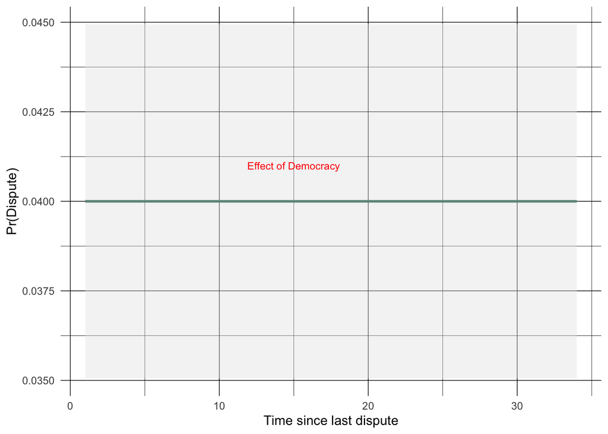

```r
# at mean data over 30 observations

atmean <- data.frame(stime=seq(1,34,1), deml=median(dp$deml), border=0, caprat=median(dp$caprat), ally=0)

predictions <- data.frame(atmean, predict(dpm1, newdata=atmean, type="response", se=TRUE)) %>% mutate(fit=round(fit, 2) )


ggplot(predictions, aes(x=stime, y=fit)) +
  geom_line(color="#005A43", size=1) +
  labs(x="Time since last dispute", y="Pr(Dispute)") +
  geom_ribbon(aes(ymin=fit-1.96*se.fit, ymax=fit+1.96*se.fit), fill="grey90", alpha=0.4) +
  theme_minimal() +
  annotate("text", x = 15, y = 0.041, label = "Effect of Democracy", color = "red", size = 3) +
  theme(panel.grid.major = element_line(color = "black",
                                        size = 0.25,
                                        linetype = 1)) +
  theme(panel.grid.minor = element_line(color = "black",
                                        size = 0.15,
                                        linetype = 1))
```

This is the case where

$$h_0(t) = \frac{1}{1+ exp(\beta_0)}$$

the baseline hazard is the constant. Even with $x$ variables, there is still no accounting for time - the $x$ effects are only shifts around this baseline hazard.

$$h_0(t) = \frac{1}{1+ exp(\beta_0+ x'\beta)}$$

this is still a constant baseline hazard with the effects of $x$ deviating around it.

### Measuring survival time

- count periods of survival up to failure. This is a counter of survival time. generate a binary variable for each survival period.
- Either include those survival dummies in the logit, or include the survival counter itself with polynomials, e.g. $t^2, t^3, \ldots$.
- interpret those coefficients as baseline hazards for groups that survive to $t_i$.
- with all $x$ variables set to zero, the probability of failure is now given by the constant and the appropriate dummy or counter coefficient.
- Note the quantity of interest is not constant across time: it’s a conditional probability; the probability of failing at $t$ given the estimated probability of survival through $t-1$ - $h(t)|S(t)$.

Here’s what the survival time counter looks like in the democratic peace data:

```r
sdpshort <- survivaldp %>% head(80) %>% dplyr::select(dyad, year, dispute, stime)

library(kableExtra)
tibble(sdpshort)%>%
    kable("html", caption="Survival Time, Democratic Peace Data") %>%
  kable_styling("striped", full_width = F) %>%
  column_spec(1, border_right = T) %>%
  column_spec(2, border_right = T) %>%
scroll_box(height = "500px", width = "100%")
```

Survival Time, Democratic Peace Data

| dyad | year | dispute | stime |
| --- | --- | --- | --- |
| 2020 | 1951 | 0 | 0 |
| 2020 | 1952 | 0 | 1 |
| 2020 | 1953 | 0 | 2 |
| 2020 | 1954 | 0 | 3 |
| 2020 | 1955 | 0 | 4 |
| 2020 | 1956 | 0 | 5 |
| 2020 | 1957 | 0 | 6 |
| 2020 | 1958 | 0 | 7 |
| 2020 | 1959 | 0 | 8 |
| 2020 | 1960 | 0 | 9 |
| 2020 | 1961 | 0 | 10 |
| 2020 | 1962 | 0 | 11 |
| 2020 | 1963 | 0 | 12 |
| 2020 | 1964 | 0 | 13 |
| 2020 | 1965 | 0 | 14 |
| 2020 | 1966 | 0 | 15 |
| 2020 | 1967 | 0 | 16 |
| 2020 | 1968 | 0 | 17 |
| 2020 | 1969 | 0 | 18 |
| 2020 | 1970 | 0 | 19 |
| 2020 | 1971 | 0 | 20 |
| 2020 | 1972 | 0 | 21 |
| 2020 | 1973 | 0 | 22 |
| 2020 | 1974 | 1 | 23 |
| 2020 | 1975 | 1 | 0 |
| 2020 | 1976 | 0 | 0 |
| 2020 | 1977 | 0 | 1 |
| 2020 | 1978 | 0 | 2 |
| 2020 | 1979 | 1 | 3 |
| 2020 | 1980 | 0 | 0 |
| 2020 | 1981 | 0 | 1 |
| 2020 | 1982 | 0 | 2 |
| 2020 | 1983 | 0 | 3 |
| 2020 | 1984 | 0 | 4 |
| 2020 | 1985 | 0 | 5 |
| 2041 | 1961 | 0 | 0 |
| 2041 | 1962 | 0 | 1 |
| 2041 | 1963 | 1 | 2 |
| 2041 | 1964 | 0 | 0 |
| 2041 | 1965 | 0 | 1 |
| 2041 | 1966 | 0 | 2 |
| 2041 | 1967 | 0 | 3 |
| 2041 | 1968 | 0 | 4 |
| 2041 | 1969 | 0 | 5 |
| 2041 | 1970 | 0 | 6 |
| 2041 | 1971 | 0 | 7 |
| 2041 | 1972 | 0 | 8 |
| 2041 | 1973 | 0 | 9 |
| 2041 | 1974 | 0 | 10 |
| 2041 | 1975 | 0 | 11 |
| 2041 | 1976 | 0 | 12 |
| 2041 | 1977 | 0 | 13 |
| 2041 | 1978 | 0 | 14 |
| 2041 | 1979 | 0 | 15 |
| 2041 | 1980 | 0 | 16 |
| 2041 | 1981 | 0 | 17 |
| 2041 | 1982 | 0 | 18 |
| 2041 | 1983 | 0 | 19 |
| 2041 | 1984 | 0 | 20 |
| 2041 | 1985 | 0 | 21 |
| 2042 | 1951 | 0 | 0 |
| 2042 | 1952 | 0 | 1 |
| 2042 | 1953 | 0 | 2 |
| 2042 | 1954 | 0 | 3 |
| 2042 | 1955 | 0 | 4 |
| 2042 | 1956 | 0 | 5 |
| 2042 | 1957 | 0 | 6 |
| 2042 | 1958 | 0 | 7 |
| 2042 | 1959 | 1 | 8 |
| 2042 | 1960 | 0 | 0 |
| 2042 | 1962 | 0 | 1 |
| 2042 | 1964 | 0 | 2 |
| 2042 | 1965 | 0 | 3 |
| 2042 | 1966 | 0 | 4 |
| 2042 | 1967 | 0 | 5 |
| 2042 | 1968 | 0 | 6 |
| 2042 | 1969 | 0 | 7 |
| 2042 | 1970 | 0 | 8 |
| 2042 | 1971 | 0 | 9 |
| 2042 | 1972 | 0 | 10 |

### Monotonic hazard

So how to deal with this, incorporating memory: thinking in terms of hazards rather than probabilities (i.e., conditional rather than unconditional probabilities), what if we measure survival time?

- The binary $y$ variable is an indicator of failure at $t$; the model estimates $f(t)$, which we’ve said is not especially informative since subjects might fail before $t$.
- Think of the number of periods up to failure as the cumulative survival time, $S(t)$.

See how we’re starting to construct the hazard rate by its parts.

Here’s an example in the democratic peace data:

$dispute = \beta_0+ \beta_1(survival)$

```r
dpm2 <-glm(dispute ~ stime, family=binomial(link="logit"), data=survivaldp )

stargazer(dpm2, type="html",  single.row=TRUE, header=FALSE, digits=3,  omit.stat=c("LL","ser"),  star.cutoffs=c(0.05,0.01,0.001),    dep.var.caption="Dependent Variable: Dispute", dep.var.labels.include=FALSE,  covariate.labels=c("Survival Time"),  notes=c("Standard errors in parentheses", "Significance levels:  *** p<0.001, ** p<0.01, * p<0.05"), notes.append = FALSE,  align=TRUE,  font.size="small")
```

|  | Dependent Variable: Dispute |
| --- | --- |
| Survival Time | -0.265*** (0.010) |
| Constant | -1.513*** (0.045) |
| Observations | 20,990 |
| Akaike Inf. Crit. | 6,208.082 |
| *Note:* | Standard errors in parentheses |
|  | Significance levels: *** p<0.001, ** p<0.01, * p<0.05 |

And here are predicted probabilities from the model.

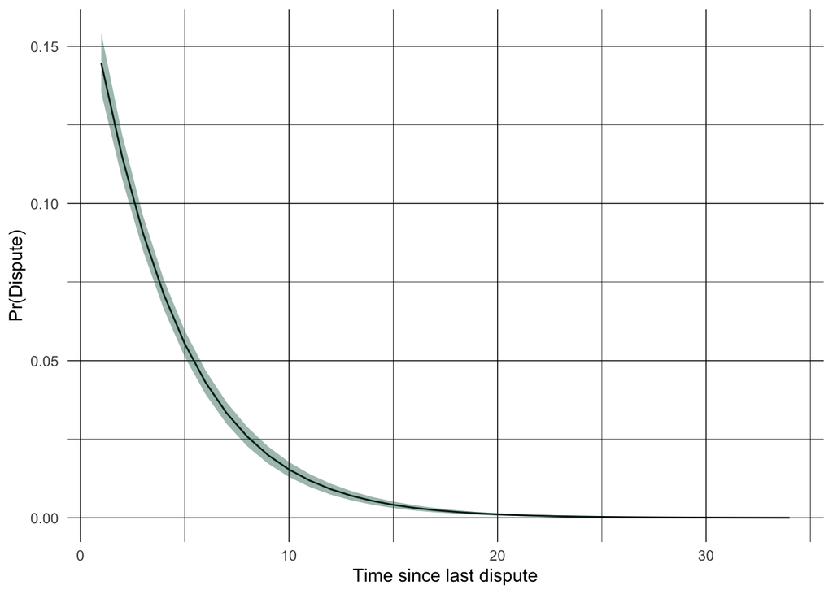

```r
atmean <- data.frame(stime=seq(1,34,1))

predictions <- data.frame(atmean, predict(dpm2, newdata=atmean, type="response", se=TRUE))

ggplot(predictions, aes(x=stime, y=fit)) +
  geom_line() +
  labs(x="Time since last dispute", y="Pr(Dispute)") +
  geom_ribbon(aes(ymin=fit-1.96*se.fit, ymax=fit+1.96*se.fit), fill="#005A43", alpha=0.4) +
  theme_minimal()+
  theme(panel.grid.major = element_line(color = "black",
                                        size = 0.25,
                                        linetype = 1)) +
  theme(panel.grid.minor = element_line(color = "black",
                                        size = 0.15,
                                        linetype = 1))
```

Where the baseline hazard is no longer constant - it can increase or decrease monotonically:

$$h_0(t) = \frac{1}{1+ exp(\beta_0 + \gamma_0(t))}$$

the baseline hazard is the constant plus the effect of survival time - the $x$ effects are shifts around this baseline hazard.

$$h_0(t) = \frac{1}{1+ exp(\beta_0 + \gamma_0(t)) + x'\beta)}$$

The baseline hazard is no longer constrained to be constant, though it can be if $\gamma_0=0$.

- This model accounts for “memory” - the QI is now the hazard.
- The hazard is not constrained to be constant, but is constrained to be monotonic.
- To relax this, we can
  - include dummy variables - these are discrete time indicators based on the counter.
  - include cubic splines or lowess estimates - these are smoothed time functions based on the counter.
  - include polynomials of the time counter.

### Non-monotonic hazard

```r
survivaldp <- survivaldp %>% mutate(stime2=stime^2, stime3=stime^3)

dpm3 <-glm(dispute ~ stime+stime2+stime3, family=binomial(link="logit"), data=survivaldp )

stargazer(dpm3, type="html",  single.row=TRUE, header=FALSE, digits=3,  omit.stat=c("LL","ser"),  star.cutoffs=c(0.05,0.01,0.001),    dep.var.caption="Dependent Variable: Dispute", dep.var.labels.include=FALSE,  covariate.labels=c("Survival Time", "Survival Time2", "Survival Time3"),  notes=c("Standard errors in parentheses", "Significance levels:  *** p<0.001, ** p<0.01, * p<0.05"), notes.append = FALSE,  align=TRUE,  font.size="small")
```

|  | Dependent Variable: Dispute |
| --- | --- |
| Survival Time | -0.830*** (0.035) |
| Survival Time2 | 0.052*** (0.004) |
| Survival Time3 | -0.001*** (0.0001) |
| Constant | -0.950*** (0.048) |
| Observations | 20,990 |
| Akaike Inf. Crit. | 5,742.615 |
| *Note:* | Standard errors in parentheses |
|  | Significance levels: *** p<0.001, ** p<0.01, * p<0.05 |

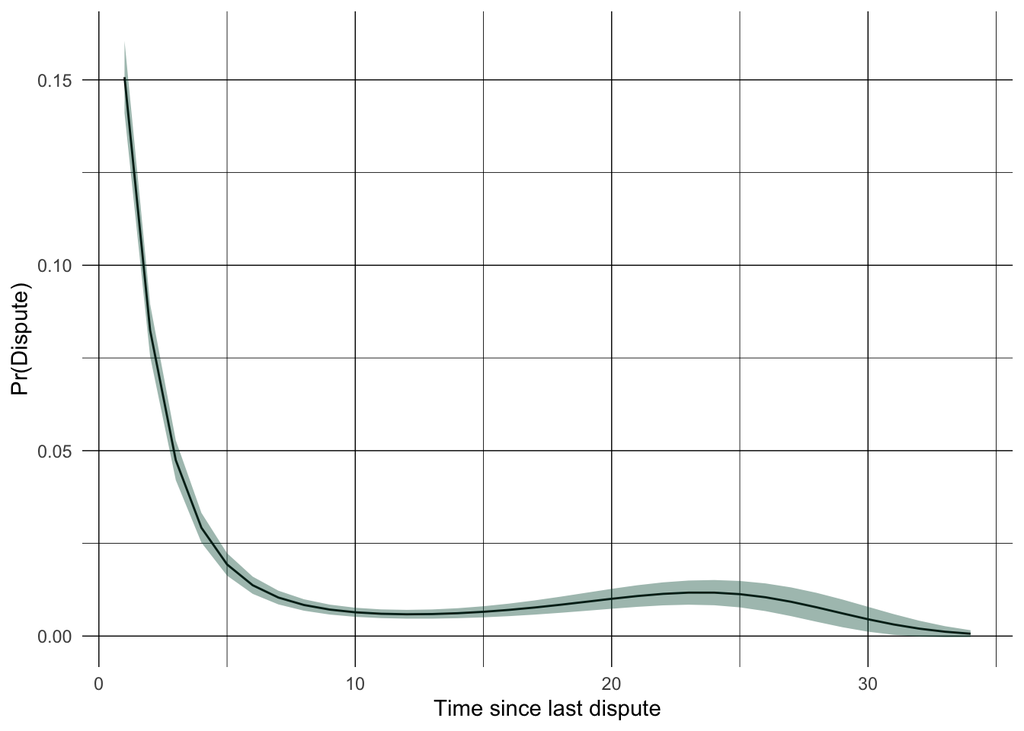

```r
atmean <- data.frame(stime=seq(1,34,1), stime2=seq(1,34,1)^2, stime3=seq(1,34,1)^3)

predictions <- data.frame(atmean, predict(dpm3, newdata=atmean, type="response", se=TRUE))

ggplot(predictions, aes(x=stime, y=fit)) +
  geom_line() +
  labs(x="Time since last dispute", y="Pr(Dispute)") +
  geom_ribbon(aes(ymin=fit-1.96*se.fit, ymax=fit+1.96*se.fit), fill="#005A43", alpha=0.4) +
  theme_minimal()+
  theme(panel.grid.major = element_line(color = "black",
                                        size = 0.25,
                                        linetype = 1)) +
  theme(panel.grid.minor = element_line(color = "black",
                                        size = 0.15,
                                        linetype = 1))
```

This last is a close approximation of a Cox proportional hazards model. The hazard is non monotonic; it nests the exponential (constant hazard), and the monotonic (Weibull) hazard, and is very general. Besides, it’s very easy to estimate and interpret.

### Understanding substantive variables in the hazard context

The survival variables now permit the baseline hazard to vary. The effects of $x$ variables can be thought of as deviations from those baseline hazards. For example, think about the models presented above, but with democracy. The estimates on democracy will shift the baseline hazard up or down.

```r
survivaldp <- survivaldp %>% mutate(stime2=stime^2, stime3=stime^3)

dpm4 <-glm(dispute ~ stime+stime2+stime3+deml, family=binomial(link="logit"), data=survivaldp )

stargazer(dpm4, type="html",  single.row=TRUE, header=FALSE, digits=3,  omit.stat=c("LL","ser"),  star.cutoffs=c(0.05,0.01,0.001),    dep.var.caption="Dependent Variable: Dispute", dep.var.labels.include=FALSE,  covariate.labels=c("Survival Time", "Survival Time2", "Survival Time3", "Democracy"),  notes=c("Standard errors in parentheses", "Significance levels:  *** p<0.001, ** p<0.01, * p<0.05"), notes.append = FALSE,  align=TRUE,  font.size="small")
```

|  | Dependent Variable: Dispute |
| --- | --- |
| Survival Time | -0.823*** (0.035) |
| Survival Time2 | 0.051*** (0.004) |
| Survival Time3 | -0.001*** (0.0001) |
| Democracy | -0.065*** (0.007) |
| Constant | -1.298*** (0.065) |
| Observations | 20,990 |
| Akaike Inf. Crit. | 5,650.709 |
| *Note:* | Standard errors in parentheses |
|  | Significance levels: *** p<0.001, ** p<0.01, * p<0.05 |

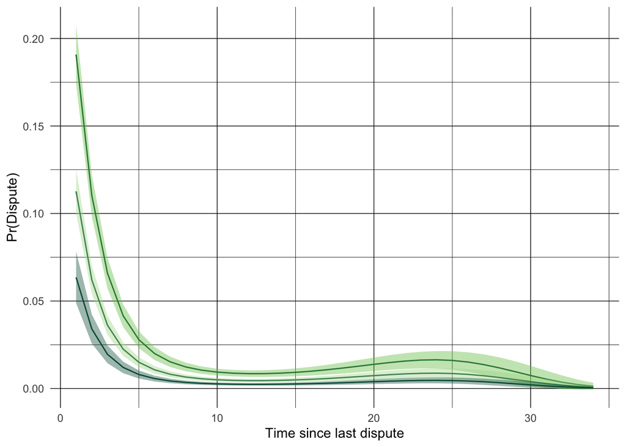

```r
dpm4 <-glm(dispute ~ stime+stime2+stime3+deml+caprat, family=binomial(link="logit"), data=survivaldp )

# copy estimation data for avg effects
dppred <- survivaldp

# df for output
df <- data.frame(time=seq(1,34,1))
for (d in seq(-10,10,10)) {
    df[paste0("p", d+10)] <- NA
  df[paste0("Se", d+10)] <- NA
}

# predictions
for (d in seq(-10,10,10)) {
  dppred$deml <- d
 for (t in seq(1,34,1)) {
  dppred$stime <- t
  dppred$stime2 <- t^2
  dppred$stime3 <- t^3
  pred <- predict(dpm4, newdata=dppred, type="response", se=TRUE)
  df[t, paste0("p", d+10)] <- mean(pred$fit, na.rm=TRUE)
  df[t, paste0("Se", d+10)] <- mean(pred$se.fit, na.rm=TRUE)
  df$time[t] <- t
}
}

# plot
ggplot(df, aes(x=time, y=p0)) +
  geom_line(color="#005A43") +
  geom_ribbon(aes(ymin=p0-1.96*Se0, ymax=p0+1.96*Se0), fill="#6CC24A", alpha=0.4) +
  geom_line(aes(y=p10), color="#005A43") +
  geom_ribbon(aes(ymin=p10-1.96*Se10, ymax=p10+1.96*Se10), fill="#A7DA92", alpha=0.4) +
  geom_line(aes(y=p20), color="#005A43") +
  geom_ribbon(aes(ymin=p20-1.96*Se20, ymax=p20+1.96*Se20), fill="#005A43", alpha=0.4) +
  labs(x="Time since last dispute", y="Pr(Dispute)") +
  theme_minimal()+
  theme(panel.grid.major = element_line(color = "black",
                                        size = 0.25,
                                        linetype = 1)) +
  theme(panel.grid.minor = element_line(color = "black",
                                        size = 0.15,
                                        linetype = 1))
```

## An alternative - transitions

What happens if we lag $y$ as we might with a continuous variable (say, in OLS), such that the estimation model is

$$y_t = \beta_0 + \beta_1(x_1) + \ldots + \gamma(y_{t-1}) + \varepsilon$$

With binary time series data, lagging $y$ would measure changes of state - these are a class known as transition models (there are a variety of these).

In general, these are interactive models where

$$Pr(y_i=1) = F(x_{i,t}\beta + y_{i,t-1}*x_{i,t} \gamma)$$

and $\gamma$ measures the difference in effect when $y_{i,t-1} = 0$ (this is just $\beta$), and when $y_{i,t-1} = 1$; denote this $\alpha$. So $\gamma = \beta - \alpha$. That difference indicates the conditional probability of state transitions from the state where $y$ takes on one value, to the state where it takes on the other value.

Transition models are useful, but measure something fundamentally different from the latent hazard rate, or the chances of failure given a history of survival. Put differently, lagging $y$ in a binary variable model does not measure memory or persistence; it does not measure the extent to which the observed value today depends on the value yesterday; it does not measure how the latent probability of failure today depends on surviving through yesterday.

# Summary

- We relaxed the assumption of temporal independence.
- Did so by conceiving of the QI as a hazard rather than a probability.
- Built a model that estimates $h(t)$ such that we don’t have to assume $h(t)$ is constant.
- Have permitted memory in the model such that the past can shape the present.

# Section 5: Classification and Model Fit

How do we know how well or poorly the model is predicting? Binary variable models are often referred to as *classification* models - they classify or sort observations into two categories. So the natural question is “how well is this sorting or classifying?”

To know that, we need to sort our predictions into zeros and ones - we need some threshold - which is related to the assumption of symmetry?

One common way to answer the “how well” question is classify predictions into zero and one categories, and generate a 2x2 table of predicted and observed values of $y$. To determine whether a predicted value of $y$ is zero or one, we need some value of $\tau$ on which to sort, then examine the intersection of:

- observed values of $y$.
- predicted values of $y$.

given the threshold, $\tau$.

## Confusion Matrix

The “confusion matrix” (I didn’t make this up) illustrates that intersection and identifies where our classification is “confused.”

```r
library(kableExtra)
# opts <- options(knitr.kable.NA = "")
df <- data.frame("Predicted Positive" = c("True Positive", "False Positive"), "Predicted Negative" = c("False Positive", "True Negative"), "Rate" = c("TPR=TP/P", "FPR=FP/N"))
row.names(df) <- c("Observed Positive", "Observed Negative")

tbl <- kbl(df, align = rep('c', 4)) |>
  column_spec(2:4, border_left = T) |>
  column_spec(1,  bold=T) |>
  column_spec(1:4, width = "2cm", color = 'white', background = '#005A43', include_thead = TRUE) |>
  column_spec(2:4, background = "inherit", color="inherit") |>
  row_spec(1, extra_css = "border-bottom: 1px solid") |>
  kable_paper("hover", bootstrap_options = c("condensed", "responsive"), full_width = F, font_size = 20)
tbl
```

[output not shown]

- True Positive Rate: correctly classify positive outcomes. This is often called “sensitivity.”
- False Positive Rate: we incorrectly classify negative outcomes ($y=0$) as positive ($y=1$). This is often called “1-specificity.” Specificity is the True Negative Rate, or the probability of correctly classifying a negative outcome ($y=0$).

## Using the Confusion Matrix to Measure Model Fit

So here’s the deal:

- estimate the model.
- generate the predicted probability $y=1$ for each observation.
- assume a threshold separating zeros and ones; usually $\tau=0.5$.
- if $Pr(y=1 \geq 0.5)$, predict a positive outcome (predict $y=1$).
- if $Pr(y=0 < 0.5)$, predict a negative outcome (predict $y=0$).
- using the observed and predicted outcomes, generate a confusion table, and compute measures of fit like “percent correctly predicted” (PCP) and “proportional reduction of error” (PRE).

### Percent Correctly Predicted (PCP)

One thing we can do is sum the main diagonal and divide by the estimation sample: $(TP+TN)/N$. This gives us the Percent Correctly Predicted (PCP).

### Proportional Reduction of Error (PRE)}

A second thing is to compute the Proportional Reduction of Error (PRE) - the difference between the correct predictions of the model versus a null model usually the unconditional frequency of $y$ - in other words, we use the Percent in the Modal Category (PCM) of the $y$ variable.

$$\frac{correct_{\text{informed}} - correct_{\text{null}}}{N - correct_{\text{null}}}$$

or

$$\frac{PCP- PMC}{1-PMC}$$

### Example: NAFTA vote, 1993

So here’s a model predicting members of the US House votes for or against the NAFTA treaty in 1993: 1 is a “yes” vote; the $x$ variables are party (Democrat) and an ideology score.

```r
nafta <- read.csv("NAFTA.csv")

naftamodel <- glm(vote ~ democrat + cope93, data=nafta, family=binomial(link="logit"))

stargazer(naftamodel, type="html",  single.row=TRUE, header=FALSE, digits=3,  omit.stat=c("LL","ser"),  star.cutoffs=c(0.05,0.01,0.001),    dep.var.caption="Dependent Variable: NAFTA vote", dep.var.labels.include=FALSE,  covariate.labels=c("Party (Democrat=1)", "Ideology (COPE score)"),  notes=c("Standard errors in parentheses", "Significance levels:  *** p<0.001, ** p<0.01, * p<0.05"), notes.append = FALSE,  align=TRUE,  font.size="small")
```

|  | Dependent Variable: NAFTA vote |
| --- | --- |
| Party (Democrat=1) | 1.990*** (0.504) |
| Ideology (COPE score) | -0.054*** (0.007) |
| Constant | 2.380*** (0.272) |
| Observations | 434 |
| Akaike Inf. Crit. | 465.904 |
| *Note:* | Standard errors in parentheses |
|  | Significance levels: *** p<0.001, ** p<0.01, * p<0.05 |

And here’s the confusion matrix from that model assuming a threshold of $\tau=.5$ - it compares the observed vote frequency against how we classify our predictions based on a predicted probability greater than or less than 0.5. This is generated using the `caret` package in R.

```r
# Load required libraries
library(caret)

# Assuming you have a fitted GLM object called 'glm_model'
# and test data 'test_data' with actual outcomes in 'test_data$actual'

test_data <- nafta %>% dplyr::select(vote, democrat, cope93) %>% mutate(actual = vote)
# Make predictions on the test data
predictions <- predict(naftamodel, newdata = test_data, type = "response")

# Create confusion matrix
# You may need to adjust the threshold (default is 0.5)
predicted_classes <- ifelse(predictions > 0.5, 1, 0)
conf_matrix <- confusionMatrix(factor(predicted_classes), factor(test_data$actual))

# Print confusion matrix
print(conf_matrix)
```

```
Confusion Matrix and Statistics

          Reference
Prediction   0   1
         0 160  77
         1  40 157

               Accuracy : 0.7304
                 95% CI : (0.686, 0.7716)
    No Information Rate : 0.5392
    P-Value [Acc > NIR] : < 2.2e-16

                  Kappa : 0.4647

 Mcnemar's Test P-Value : 0.0008741

            Sensitivity : 0.8000
            Specificity : 0.6709
         Pos Pred Value : 0.6751
         Neg Pred Value : 0.7970
             Prevalence : 0.4608
         Detection Rate : 0.3687
   Detection Prevalence : 0.5461
      Balanced Accuracy : 0.7355

       'Positive' Class : 0
```

This all depends on the threshold (.5) - in the case of a Congressional vote, especially a relatively close vote like this one, the threshold might not be crazy. But it might be in other cases, and arbitrarily choosing a value for $\tau$ is problematic. So another approach is to compute the ROC curve.

What makes this work relatively well in the NAFTA context? As you’ll see below, it works less well in the democratic peace models.

### Example: Democratic Peace

Here’s a basic democratic peace model:

```r
dp <- read_dta("/Users/dave/Documents/teaching/501/2023/slides/L7_limiteddv/code/dp.dta")

dpm1 <-glm(dispute ~ border+deml+caprat+ally, family=binomial(link="logit"), data=dp )

stargazer(dpm1, type="html",  single.row=TRUE, header=FALSE, digits=3,  omit.stat=c("LL","ser"),  star.cutoffs=c(0.05,0.01,0.001),    dep.var.caption="Dependent Variable: Dispute", dep.var.labels.include=FALSE,  covariate.labels=c("Shared Border", "Democracy", "Capabilities Ratio", "Allies"),  notes=c("Standard errors in parentheses", "Significance levels:  *** p<0.001, ** p<0.01, * p<0.05"), notes.append = FALSE,  align=TRUE,  font.size="small")
```

|  | Dependent Variable: Dispute |
| --- | --- |
| Shared Border | 1.221*** (0.078) |
| Democracy | -0.071*** (0.007) |
| Capabilities Ratio | -0.003*** (0.0004) |
| Allies | -0.806*** (0.080) |
| Constant | -3.492*** (0.075) |
| Observations | 20,990 |
| Akaike Inf. Crit. | 7,011.947 |
| *Note:* | Standard errors in parentheses |
|  | Significance levels: *** p<0.001, ** p<0.01, * p<0.05 |

Let’s generate the confusion matrix for the democratic peace model, threshold set at $\tau =0.5$:

```r
library(kableExtra)
# opts <- options(knitr.kable.NA = "")
df <- data.frame("Predicted Positive" = c("0", "0"), "Predicted Negative" = c("897", "19,245"), "Rate" = c("TPR=0/897=0", "FPR=0/19,245=0"))
row.names(df) <- c("Observed Positive", "Observed Negative")

tbl <- kbl(df, align = rep('c', 4)) |>
  column_spec(2:4, border_left = T) |>
  column_spec(1,  bold=T) |>
  column_spec(1:4, width = "2cm", color = 'white', background = '#005A43', include_thead = TRUE) |>
  column_spec(2:4, background = "inherit", color="inherit") |>
  row_spec(1, extra_css = "border-bottom: 1px solid") |>
  kable_paper("hover", bootstrap_options = c("condensed", "responsive"), full_width = F, font_size = 20)
tbl
```

|  | Predicted.Positive | Predicted.Negative | Rate |
| --- | --- | --- | --- |
| Observed Positive | 0 | 897 | TPR=0/897=0 |
| Observed Negative | 0 | 19,245 | FPR=0/19,245=0 |

The problem is $\tau$; at $\tau=.5$ we get none of the ones correct. Here’s the democratic peace at $\tau = 0.1$:

```r
library(kableExtra)
# opts <- options(knitr.kable.NA = "")
df <- data.frame("Predicted Positive" = c("303", "1,764"), "Predicted Negative" = c("594", "17,481"), "Rate" = c("TPR=303/897=.34", "FPR=1,764/19,245=0.092"))
row.names(df) <- c("Observed Positive", "Observed Negative")

tbl <- kbl(df, align = rep('c', 4)) |>
  column_spec(2:4, border_left = T) |>
  column_spec(1,  bold=T) |>
  column_spec(1:4, width = "2cm", color = 'white', background = '#005A43', include_thead = TRUE) |>
  column_spec(2:4, background = "inherit", color="inherit") |>
  row_spec(1, extra_css = "border-bottom: 1px solid") |>
  kable_paper("hover", bootstrap_options = c("condensed", "responsive"), full_width = F, font_size = 20)
tbl
```

|  | Predicted.Positive | Predicted.Negative | Rate |
| --- | --- | --- | --- |
| Observed Positive | 303 | 594 | TPR=303/897=.34 |
| Observed Negative | 1,764 | 17,481 | FPR=1,764/19,245=0.092 |

At $\tau = 0.1$, we get a TPR = 0.34 and FPR = 0.092. The PCP = (303+17481)/20142 = 0.88 …which is lower, but we get about 1/3 of the ones correct.

## Receiver-Operator Characteristic (ROC) Curves

The problem is choosing the threshold - imagine that we compute a confusion matrix for all possible thresholds, $\tau=.01, .02, .03 \ldots 1$, then compute TPR and FPR, and plot them against one another. This is an ROC curve.

ROCs originate in efforts to distinguish signal from noise in radar returns - the British built a radar system before WWII to detect German air attacks; they had the problem of distinguishing planes (signal) from flocks of geese (noise). As the turned up the sensitivity of the radar, they more often correctly detected planes, but they also lacked specificity and detected more geese too. So there was a tradeoff between sensitivity (correctly identifying positive signals as positive) and specificity (incorrectly identify negative signals as positive).

ROCs measure these two dimensions and graph them against one another:

- sensitivity - true positive rate at every possible latent threshold between zero and one.
- 1- specificity - false positive rate at every possible latent threshold between zero and one. This is 1 minus the True Negative Rate

Here’s the ROC for the NAFTA model - we’ll use the `pROC` package in R to compute the ROC and plot it:

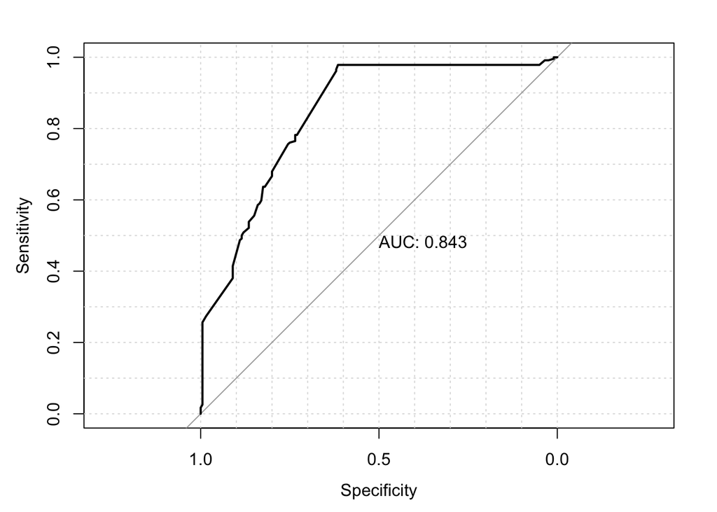

```r
library(pROC)

# NAFTA

naftaroc <- roc(test_data$actual, predictions, plot=TRUE, grid=TRUE, partial.auc.correct=TRUE,
         print.auc=TRUE)
```

## ROC Intepretation

- the diagonal is a model guessing randomly zero or one - no better than a coin toss.
- above that line, the model is improving our classification over random guesses.
- the top left corner would indicate a model that classifies perfectly - 100% sensitivity (TPR), and 0% FPR.
- below the diagonal line, the model is classifying worse than a coin toss would.
- we can compute the Area Under the Curve (AUC) as a percentage - AUC is often reported to indicate model fit. In the NAFTA model, the AUC is .843. AUC closer to one indicates better fit; closer to .5 indicates worse fit, similar to random guessing.
- we can plot ROCs from different models on the same space and compare their fits.
- The x-axis is 1-specificity, or the False Positive Rate.

## ROC Democratic Peace

Here’s we compare fit for two models, one including “borders,” the other excluding it. Here are the two models :

```r
dp <- read_dta("/Users/dave/Documents/teaching/501/2023/slides/L7_limiteddv/code/dp.dta")

dpm1 <-glm(dispute ~ border+deml+caprat+ally+border, family=binomial(link="logit"), data=dp )
dpm2 <-glm(dispute ~ deml+caprat+ally, family=binomial(link="logit"), data=dp )

stargazer(list(dpm1,dpm2), type="html",  single.row=TRUE, header=FALSE, digits=3,  omit.stat=c("LL","ser"),  star.cutoffs=c(0.05,0.01,0.001),    dep.var.caption="Dependent Variable: Dispute", dep.var.labels.include=FALSE,  covariate.labels=c("Shared Border", "Democracy", "Capabilities Ratio", "Allies"),  notes=c("Standard errors in parentheses", "Significance levels:  *** p<0.001, ** p<0.01, * p<0.05"), notes.append = FALSE,  align=TRUE,  font.size="small")
```

|  | Dependent Variable: Dispute |  |
| --- | --- | --- |
|  | (1) | (2) |
| Shared Border | 1.221*** (0.078) |  |
| Democracy | -0.071*** (0.007) | -0.078*** (0.007) |
| Capabilities Ratio | -0.003*** (0.0004) | -0.005*** (0.0005) |
| Allies | -0.806*** (0.080) | -0.374*** (0.076) |
| Constant | -3.492*** (0.075) | -2.979*** (0.064) |
| Observations | 20,990 | 20,990 |
| Akaike Inf. Crit. | 7,011.947 | 7,262.635 |
| *Note:* | Standard errors in parentheses |  |
|  | Significance levels: *** p<0.001, ** p<0.01, * p<0.05 |  |

And compute the ROC for each model - here Claude.ai and I have written a function to compute the ROC and AUC for each model, and then plot them on the same space.

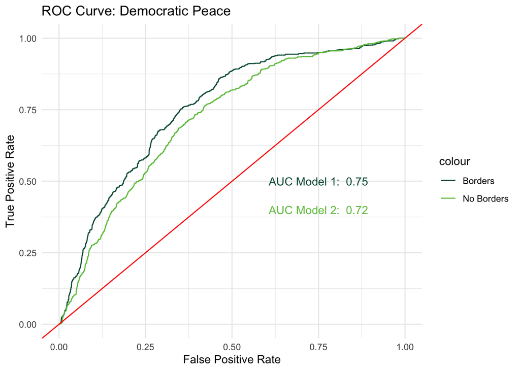

```r
# part written by Claude.ai
# compute ROC curve
compute_roc <- function(actual, predictions) {
  # Sort actual and predictions in descending order of predicted probabilities
  sorted_data <- data.frame(actual, predictions)
  sorted_data <- sorted_data[order(sorted_data$predictions, decreasing = TRUE), ]

  # Initialize variables
  n_positive <- sum(actual)
  n_negative <- length(actual) - n_positive
  tp <- 0
  fp <- 0
  tpr <- c()
  fpr <- c()

  # Iterate over sorted data
  for (i in 1:nrow(sorted_data)) {
    if (sorted_data$actual[i] == 1) {
      tp <- tp + 1
    } else {
      fp <- fp + 1
    }

    # Calculate true positive rate (TPR) and false positive rate (FPR)
    tpr <- c(tpr, tp / n_positive)
    fpr <- c(fpr, fp / n_negative)
  }

  # Create ROC curve
  roc_curve <- data.frame(fpr, tpr)
  return(roc_curve)
}

# Function to compute AUC
compute_auc <- function(fpr, tpr) {
  # Sort FPR and TPR
  ord <- order(fpr)
  fpr <- fpr[ord]
  tpr <- tpr[ord]

  # Compute AUC using trapezoidal rule
  auc <- sum((fpr[-1] - fpr[-length(fpr)]) * (tpr[-1] + tpr[-length(tpr)]) / 2)
  return(auc)
}

# Democratic Peace models

test_dataB <- dp %>% dplyr::select(border,deml,caprat,ally) %>%
  mutate(actual = dp$dispute)

test_dataNB <- dp %>% dplyr::select(deml,caprat,ally) %>%
  mutate(actual = dp$dispute)

# Make predictions on the test data
predictionsB <- predict(dpm1, newdata = test_dataB, type = "response")
predictionsNB <- predict(dpm2, newdata = test_dataNB, type = "response")


roc_curveB <- compute_roc(test_dataB$actual, predictionsB)
#AUC
auc_border <- compute_auc(roc_curveB$fpr, roc_curveB$tpr)
roc_curveNB <- compute_roc(test_dataNB$actual, predictionsNB)
auc_noborder <- compute_auc(roc_curveNB$fpr, roc_curveNB$tpr)

# ROC Plot, pasting auc_border and auc_noborder on plot

ggplot() +
  geom_line(data = roc_curveB, aes(x = fpr, y = tpr, color = "Borders")) +
  geom_line(data = roc_curveNB, aes(x = fpr, y = tpr, color = "No Borders")) +
  geom_abline(intercept = 0, slope = 1, linetype = "solid", color = "red") +
  labs(title = "ROC Curve: Democratic Peace", x = "False Positive Rate", y = "True Positive Rate") +
  theme_minimal() +
  scale_color_manual(values = c("Borders" = "#005A43", "No Borders" = "#6CC24A"))+
  annotate("text", x = 0.75, y = 0.5, label = paste("AUC Model 1: ", round(auc_border, 2)), color = "#005A43") +
  annotate("text", x = 0.75, y = 0.4, label = paste("AUC Model 2: ", round(auc_noborder, 2)), color = "#6CC24A")
```

```r
#bucolors<-list("#005A43","#6CC24A", "#A7DA92", "#BDBEBD", "#000000" )
```

Also, note the measure Area Under the Curve (AUC) for each model - the AUC is often reported to indicate model fit. The AUC for the model including borders is 0.75, while the AUC for the model excluding borders is 0.72. A model with an AUC of 0.5 is no better than a coin toss, while a model with an AUC of 1 is perfect.

# Model fit in ML models

Measures of model fit in ML models are relatively simple - the topic is very important insofar as our goal is to evaluate how well models fit the data, and to compare how different models fit.

Comparing model fit in the linear model we mostly accomplished using F-tests - the methods here are analogous. The *information criterion* methods covered below have exact analogs in the linear model, using the explained sum of squares rather than the log-likelihood.

## Single Coefficient Estimates

One property of MLEs is they are asymptotically multivariate normal; inference is straightforward because the variances are also normal so the ratio of $\beta /se$ is a z-score.

## Model Evaluation

Most commonly, we evaluate model fit using one of the “trinity” of tests:

- log-likelihood ratio tests (LLR)
- Wald tests
- Lagrange Multiplier tests (LM)

The first two are the most common, and it’s not clear one is better than the other.

### Log-Likelihood Ratio Test

The LLR test requires estimating two models - a null or constrained model, ($M_0$), and informed (unconstrained) model ($M_1$) - it compares the heights of the log-likelihood functions of the two models:

$$\chi^2 = -2 (ln\mathcal{L}(M_0) - ln\mathcal{L}(M_1))$$

The log-likelihoods here are literally the values of the $ln\mathcal{L}$ at the estimated maxima of the functions. Their difference is distributed $\chi^2$ with $k_1-k_0$ degrees of freedom.

The LLR is simple to compute (you can do it in your head), but requires estimating two **nested** models. Recall, two models are nested iff the regressors in the constrained model are a strict subset of those in the unconstrained model, and the samples are identical.

### Wald $\chi^2$

The Wald test is similar, but only requires the unconstrained or informed model. During maximization, it examines the distance between $M_0$ and $M_1$, and weights that distance by the rate of change between the two (second derivative). If the distance is large and the rate of change is fast, the informed model improves a good bit on the uninformed one. You can imagine other combinations of distance and curvature. Long (p. 88) has a great illustration of this.

### In Practice

These two tests are asymptotically equivalent. In practice, it makes little difference in most cases which you choose, provided the models are nested.

Stata reports LLR for most models, but reports Wald if you request robust standard errors.

### Limits

The limits of these tests is they apply only to nested models - models where the regressors in the constrained model are a strict subset of those in the unconstrained model and where the samples are identical.

### Information Criterion Tests

Alternatively, we can use information criterion tests - the two most common are the Akaike and Bayesian Information Criteria tests (AIC, BIC). These are both formulated to penalize likelihoods for the number of parameters estimated; this in effect rewards better specification (good variables, but few) and penalizes “garbage can” approaches (including lots of poor predictors).

IC tests are useful for either nested or nonnested models. This is a significant though under-appreciated virtue of such tests.

### Akaike and Bayesian Information Criterion tests

$$AIC = -2 ln(\mathcal{L}) + 2k$$

$$BIC = -2 ln(\mathcal{L}) + ln(N) k$$

where $k$ is the number of parameters.

#### Process

*AIC:* Estimate model 1; generate the AIC. Estimate model 2; generate the AIC. The model with the smaller AIC is the preferred model (see Long 1997: 110).

*BIC:* Estimate model 1; generate the BIC. Estimate model 2; generate the BIC. Compute $BIC_1 - BIC_2$ - the smaller BIC value is the preferable model. The strength of the test statistic is given by Rafferty (1996): absolute value of this difference 0-2 = weak; 2-6= Positive; 6-10= Strong; greater than 10 = Very Strong (see Long 1997: 112).